# The Foreign Policy Impact of Trade-Based Status Gains: When China Overtakes the US as Top Trade Partner

Manoel Galdino (University of São Paulo; mgaldino@usp.br)

2026-05-16

Abstract

Word count: 14,998

# Introduction

“China overtakes US as Brazil’s top trade partner”. That was a headline in many Brazilian newspapers in 2009 (Rodrigues 2009). The BBC ran a similar headline in 2021, when China surpassed the United States as the EU’s biggest trading partner (BBC News 2021). Sensing the symbolic weight of the milestone in Brazil, President Lula da Silva promptly announced a high-profile trip to Beijing, flanked by an unusually large business delegation.

Do discrete rank reversals in trade hierarchies — particularly when a rising power displaces the hegemon — produce foreign policy realignment beyond what continuous trade growth predicts?

The status literature (Renshon 2016; Ward 2017; Dafoe, Renshon, and Huth 2014) focuses almost exclusively on status deficits and conflict. It offers limited theoretical guidance predicting that a state gaining trade-based status would receive diplomatic concessions. The literature on status effects of rank changes exists in domestic politics (Anagol and Fujiwara 2016; Fujiwara and Sanz 2020) but has never been extended to international politics.

An extensive empirical literature shows that as a country’s trade dependence on China accumulates, its UN-voting distance from Beijing tends to fall (Kastner and Pearson 2021; Yan and Zhou 2021; Morgan 2019; Flores-Macías and Kreps 2013), the same being true for Brazil and China in particular (Neto and Malamud 2015; Mourón and Urdinez 2014). Analysts interpret this association in three ways: coercive leverage, i.e., China rewards or punishes to shape votes (Tanner 2007; Reilly 2013), interest redefinition (growing commerce makes cooperation intrinsically valuable), and societal pressure (business lobbies or public opinion pull leaders toward Beijing). What these perspectives share is the assumption that influence scales smoothly with commercial exposure: the more trade, the more alignment — no particular trade share or moment is distinguished from another.

Research in cognitive psychology and political communication, by contrast, emphasizes that actors respond disproportionately to salient thresholds – events that break routine patterns and become focal in media and politicians’ agendas (Baekgaard et al. 2019; Sheffer et al. 2018; Edwards and Wood 1999; Mintz and Geva 1997; Mercer 2017).

While most studies of status emphasized how lacking status drives risk-acceptant behavior and conflict, there is only anecdotal evidence that status yields tangible diplomatic dividends (Götz 2021). As a result, we know surprisingly little about the downstream effects when a state’s status actually rises.

We argue that rank reversals deliver discrete status changes that, processed as coarse categories, trigger disproportionate media salience and foreign policy realignment, beyond what gradual trade accumulation predicts. The salience cue can arrive abruptly, but the foreign-policy response need not be a one-year jump. Diplomatic positions are embedded in prior votes, bureaucratic routines, coalition commitments, and reputational costs, so governments may adjust gradually as the new status category becomes politically usable. This effect is more likely when other cues increase salience, such as the former trade partner being the hegemon or the reversal overcomes a long-run historic pattern.

To develop and initially probe our theory, we focus on the most likely case: Brazil. The US was Brazil’s top trade partner for approximately 80 years, making the displacement maximally salient. Brazil has a free press (media channels can operate freely); Brazil is a regional power, not a small state, which makes coercion unlikely. Most-likely cases are well-suited for theory generation with confirmatory value: if the effect doesn’t appear here, it’s unlikely to appear anywhere. We follow a structured hybrid approach: the reduced-form prediction (rank reversal → alignment) is tested in Brazil (SDiD) and cross-country (DiD), while the salience mechanism is proposed and probed using the Brazilian case and NLP media evidence.

To credibly show that the overtaking of the US by China as Brazil’s top trade partner has a causal effect on Brazil’s foreign policy orientation, we use a synthetic difference-in-differences approach. We measure the outcome as the absolute distance in UNGA ideal point estimation (Bailey, Strezhnev, and Voeten 2017) between Brazil and China over 1997-2015. The SDiD point estimate corresponds to an estimated 40.8% average reduction in Brazil’s ideological distance from China over the post-2009 period relative to the synthetic counterfactual. It is not an estimate of a visual discontinuity or of the one-year change in 2009.

As Brazil is a single case, we test the theory that status change impacts foreign policy using a cross-country design on all countries where the United States was the top trade partner. We compare those where China eventually displaced the US (the treatment) with those where it did not (control group), using a counterfactual estimator with interactive fixed effects (Liu, Wang, and Xu 2024) that accommodates treatment switching – four of the eight treated countries see the USA regain the top position. The results are consistent with the case study, and exit-aligned analysis shows the effect dissipates when treatment turns off.

To illuminate the mechanisms behind the effect of status change, we perform a deep analysis of the Brazilian case, showing a plausible channel through which rank appears as a cue that may trigger change in policy making: the media’s role in publicizing and thus legitimizing this newfound status.

This study provides the first systematic evidence that trade rank reversals produce foreign policy realignment, with patterns consistent with a media-salience mechanism. Residual endogeneity from shared structural features of commodity-exporting economies cannot be entirely ruled out, though the IFE latent factors and leave-one-out robustness checks mitigate this concern. The study questions the idea in the literature that status gains are mostly illusory (Mercer 2017). It also has broad implications for the study of economic ties with an emerging power and the foreign policy of countries. Similar status change effects may also shape how other economic variables (such as Foreign Direct Investment, aid, and loans) impact the foreign policy of countries.

# Trade, Status, and Political Alignment

An extensive literature examines how trade with China affects foreign policy. The proposed mechanisms vary – coercive leverage, where China rewards or punishes to shape votes (Tanner 2007; Reilly 2013); interest redefinition, where deepening economic ties create vested interests that lobby on behalf of Beijing (Kastner and Pearson 2021); soft power and societal pressure, where economic integration transforms public and elite opinion (Morgan 2019; Kastner and Pearson 2021); and structural power, where China’s rise as a great power pulls countries toward its orbit (Struver 2014; Schenoni and Leiva 2021; Neto 2011; Mourón and Urdinez 2014). What these perspectives share is the assumption that influence scales smoothly with commercial exposure: the more trade, the more alignment – no particular trade share or moment is distinguished from any other.

Yet the empirical record shows reality is messier. Reverse causality remains a concern: political alignment may drive trade rather than the reverse (Haibin 2010; Coutinho and Rodriguez 2024; Fuchs and Klann 2013; Yan and Zhou 2021; Chen and Zhou 2021; Aiyar, Malacrino, and Presbitero 2024)[^1]. More substantively, if gradual trade growth consistently produced alignment, we should observe a monotonic relationship. Instead, Carmody, Dasandi, and Mikhaylov (2020) find the opposite for Africa: countries that increased trade with China voted *more* with the United States, not less – consistent with hedging rather than bandwagoning. Garcia-Herrero, Storella, and Weil (2024) show that UNGA alignment with China has remained remarkably stable despite China’s dramatic economic rise, suggesting that continuous trade growth alone does not move the needle on foreign policy. If gradual trade growth does not consistently produce alignment, what does?

## Why Rank Reversals Matter

Status has been extensively studied in international relations (Dafoe, Renshon, and Huth 2014; Miller et al. 2015; Renshon 2016; Renshon, Dafoe, and Huth 2018; Duque 2018; Parlar Dal 2019; Götz 2021; Røren 2024). A standard definition is the ranking or relative standing of a state (MacDonald and Parent 2021). This definition, however, conflates a continuous measure (relative standing) with an ordinal one (rank position). Being first is qualitatively different from being second, and that distinction matters for how actors process information and allocate attention. We distinguish between *trade status* – the ordinal position of a trade partner in a country’s hierarchy of commercial relationships – and *status shock* – the discrete event of a rank reversal. In an experimental setup, status is the treatment; rank reversal is the manipulation. Our argument concerns the downstream consequences of status shocks, not status seeking, status anxiety, or military conflict – the phenomena that dominate the existing IR status literature.

The micro-foundation for why rank matters comes from coarse categorization – the tendency to rely on broad, easily processed bins rather than fine-grained metrics when confronting complexity (Graeber, Roth, and Sammon 2025; Enke 2024). Actors – media editors, policymakers, business leaders – attend to categories like “top trade partner” as well as tracking continuous trade shares. The relevant categories here are “US = top partner” (a cognitive default entrenched by decades of commercial primacy) versus “China = top partner” (a disruptive reclassification). The rank reversal does not bring new information about trade volumes – those data are continuously available. What it brings is a *categorical reclassification* that captures attention precisely because it disrupts an entrenched bin. Even redundant information shifts attention when it alters salient categories (Conlon 2025; Bordalo, Gennaioli, and Shleifer 2022), and people tend to neglect the correlated structure of information and treat novel framings as independent signals (Enke and Zimmermann 2017).

The effect of rank on political decisions is well documented in domestic politics. Rank reversals produce bandwagon effects in elections (Anagol and Fujiwara 2016; Granzier, Pons, and Tricaud 2023), regression discontinuities at the boundary of winning versus losing affect subsequent political careers (Folke, Persson, and Rickne 2016; Fujiwara and Sanz 2020), and similar rank-based thresholds coordinate behavior across diverse actors. The rank reversal functions as a focusing event by breaking an entrenched cognitive category. Yet no study has examined whether rank effects operate in international politics, despite the plausibility that they do. Status is widely acknowledged to matter in world politics, but there is no quantitative study estimating how a positive status shock translates into concrete policy changes or political alignment.

## Two Claims: Attention and Policy Response

Our theory rests on two distinct claims. *Claim 1 (Attention)*: A rank reversal produces a disproportionate increase in media salience. The micro-foundation is coarse categorization: the reclassification from “second partner” to “first partner” triggers a categorical reframing in news coverage. The amplification occurs through agenda-setting (Edwards and Wood 1999) – the media transforms the categorical reclassification into a focal event for national attention. Since this is a bounded rationality reaction, it is plausible that it would be temporary: as the new status becomes the cognitive default, salience fades. We provide evidence for this claim directly using NLP analysis of Brazilian newspaper coverage.

*Claim 2 (Policy Response)*: The salience shock translates into foreign policy realignment through complementary channels, but the response can be gradual. First, a cognitive channel: poliheuristic theory (Mintz 2004, 2005; Mintz and Geva 1997) predicts that decision-makers use non-exhaustive search heuristics, and the salience spike causes the new trade status to enter their consideration sets, even if the underlying economic relationship was previously discounted. The role of cues and heuristics in foreign policy decisions has been discussed in international relations (Jabarian and Sartori 2024). Second, an audience cost channel: once the media publicizes the new status, leaders face reputational incentives to align discourse and action with the newly salient relationship (Fearon 1994; Tomz 2007). Third, a coordination channel: the rank reversal creates a focal point in the Schelling sense around which business lobbies, diplomats, and public opinion coordinate their demands for policy adjustment. These channels work through institutions that carry memory: diplomatic services preserve prior positions, coalition commitments constrain abrupt reversals, and leaders may prefer incremental movement to avoid appearing opportunistic. The SDiD therefore identifies their combined reduced-form effect over the post-treatment period, not a separate instantaneous mechanism.

We are explicit about the limits of our design. The SDiD estimates the combined reduced-form effect of the rank reversal on alignment through all channels. The NLP media analysis provides suggestive evidence for Claim 1 (attention). Claim 2 – how salience translates into votes – is theorized but not causally identified. We provide convergent evidence consistent with an attention channel, while acknowledging that the policy response channel remains theorized rather than directly identified.

## Hypotheses

From the theoretical building blocks above, we derive four testable hypotheses.

The first hypothesis is the main effect of interest and is related to the reduced-form specification.

Hypothesis 1 (Main Effect): Rank reversals – where China displaces the incumbent top trade partner – produce a lower average post-reversal UNGA voting distance from China, beyond what gradual trade growth predicts. This follows from coarse categorization (the rank reversal is a category disruption) that opens a window for policy change, even if the observable policy response accumulates over several post-reversal years.

Our theorization also makes predictions about mechanisms, of which we specify here the ones we can test or provide evidence consistent with in the paper.

Hypothesis 2 (Hegemon Moderation): The effect is larger when an emerging power displaces the hegemon, compared to when the displaced partner is any other country. Coarse categorization theory predicts that disrupting a more entrenched cognitive category, and “US = top partner” is among the most deeply entrenched, produces a larger attention shock (Graeber, Roth, and Sammon 2025).

Hypothesis 3 (Media Salience): Media coverage of the trade relationship increases disproportionately at the moment of the rank reversal, rather than tracking gradual trade growth. This is the direct observable implication of Claim 1 and is testable with the NLP analysis.

Hypothesis 4 (Temporal Dynamics): The salience shock is immediate, but the alignment response may build gradually and then attenuate as the new status becomes the cognitive default. Salience is by nature temporary – the new rank normalizes and media attention shifts to other topics – while policy adjustment is constrained by diplomatic inertia, prior commitments, and reputational costs. This hypothesis is discriminating against structural bandwagoning and coercion, which predict *persistent* effects. However, interest-based and trade-dependence theories may also predict transient effects if the underlying interests themselves reverse.

## Scope Conditions

The status-salience mechanism operates under conditions that follow from the theoretical building blocks above. First, the displaced partner must be geopolitically significant, ideally the hegemon. Coarse categorization theory predicts that disrupting a more prominent cognitive category produces a larger attention shock. Second, the media amplification channel requires a free or active press; in countries with restricted press freedom, the rank reversal may go unreported, muting the salience mechanism. This follows directly from the agenda-setting literature (Edwards and Wood 1999). Third, the duration of the prior relationship matters: the longer the displaced partner held the top position, the more entrenched the existing category and the more disruptive the reversal (Mintz and Geva 1997). Fourth, democratic accountability moderates the effect, as media salience is more consequential where public opinion constrains foreign policy choices. Fifth, the rank reversal should be exogenous to deliberate trade diversification policy – if a government actively pursued the rank reversal as part of a broader realignment strategy, the effect captures policy intent rather than the salience mechanism. In the cross-country analysis, we test scope condition 1 directly by comparing specifications where China displaced the United States versus any partner, and scope conditions 2 and 3 enter as covariates (press freedom and US streak).

## Causal Framework

The causal claim of the present paper can be summarized by the simplified Directed Acyclic Graph (DAG) – a diagram that visually represents assumed causal relationships – below. We represent the main variables and proposed mechanisms, without any confounding variables, to clarify the argument. We discuss the identification strategy in the next section.

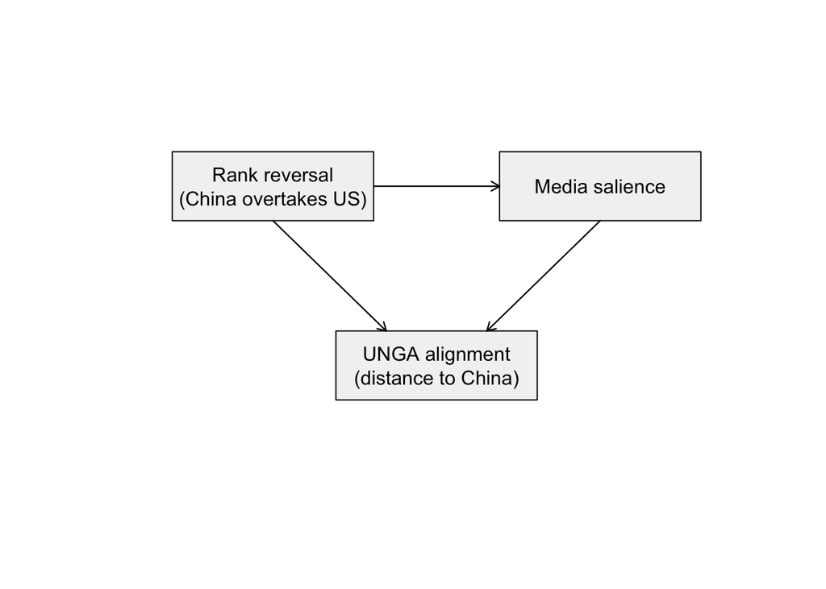

Simplified DAG of the causal relationship between China’s status as top trade partner and foreign policy alignment. Note: Unit = conceptual diagram (no numeric scale). Standard error = not applicable. Cluster = not applicable. Time window = conceptual graph; treatment onset is 2009 in Brazil and country-specific in panel analyses. Treatment definition = Treatment indicator equals 1 in any year China is currently the top export destination; turns off if USA regains the position (switching treatment).

# Methodology

## Brazilian Case

For the Brazilian case, we employ the synthetic difference-in-differences (SDiD) method (Arkhangelsky et al. 2021), which combines the strengths of standard DiD and the synthetic control method (SCM). SDiD assigns unit weights so that the synthetic control matches the treated unit’s pre-treatment trajectory, and time weights so that the comparison focuses on periods closest to treatment onset. Unlike SCM, it retains unit fixed effects, accounting for time-invariant unobservables. Unlike standard DiD, it does not require that all control units follow the same trend as the treated unit – an assumption that is implausible here given the 2008 economic crisis and other concurrent shocks. A formal comparison of the DiD, SCM, and SDiD estimating equations is provided in the Appendix.

Following Hirshberg and Klosin (2024), we augment the model with time-varying covariates $X_{it}$ for more accurate pre-treatment matching. The estimating equation is:

$$\bigl(\hat{\tau}_{ATT}^{\text{SDiD}}, \hat{\mu}, \hat{\alpha},
\hat{\beta}, \hat{\gamma} \bigr)
=
\operatorname*{arg\,min}_{\tau_{ATT},\mu,\beta, \alpha, \gamma}
\sum_{i=1}^{N}\sum_{t=1}^{T}
\bigl(Y_{it}- \mu- \alpha_i - \beta_t-D_{it}\tau_{ATT} -X_{it}\gamma
\bigr)^2\,
\hat{w}^{\text{SDiD}} \hat{\lambda}^{\text{SDiD}}_t$$

where $\hat{w}^{\text{SDiD}}$ are unit weights and $\hat{\lambda}^{\text{SDiD}}_t$ are time weights, both estimated from pre-treatment data. Standard errors are computed using the placebo variance estimator proposed by Arkhangelsky et al. (2021), which estimates the variance of the treatment effect by computing pseudo-treatment effects on each control unit.

In this setup, $\tau_{ATT}^{\text{SDiD}}$ is an average treatment effect for Brazil over the weighted post-treatment period. Because $D_{it}$ equals 1 from 2009 onward, the estimate summarizes Brazil’s average post-2009 gap relative to the synthetic counterfactual. It should therefore be interpreted as an accumulated post-treatment effect, not as evidence that UNGA alignment changed discontinuously in 2009 itself.

## Cross-Country Design

Although the Brazilian case is a credible strategy to study the causal effect of status change, it is still $n=1$, and does not allow generalization beyond its specific features. Furthermore, we cannot rule out that the explanation resides in something specific to Lula da Silva’s or the Workers’ Party’s presidency in the period considered, or rule out alternative explanations of potential confounders that happened at a similar time, such as the global economic crisis in the aftermath of Lehman Brothers’ fallout and how the 2008 Beijing Summer Olympics changed China’s status.

To address such challenges, we examine all countries in our sample that had the US as their top trade partner and consider the effect of China overtaking the US. An important empirical feature is that this treatment is not absorbing: four of the eight treated countries experience treatment reversals – the USA regains the top position after China held it temporarily. Standard staggered DiD estimators such as Callaway and Sant’Anna (2021) assume absorbing treatment and cannot accommodate this switching pattern. For Brazil, treatment is absorbing since China has remained the top partner since 2009. For the cross-country design, we use a switching indicator ($D_{it} = 1$ only while China currently holds the top rank) because this reflects the empirical reality. The SDiD ATT for Brazil is therefore an average across all post-treatment years, which includes both the initial salience shock and any subsequent attenuation predicted by H4.

We therefore adopt the counterfactual estimator with interactive fixed effects (IFE) proposed by Liu, Wang, and Xu (2024) as our main cross-country specification. The `fect` framework estimates counterfactual outcomes for treated observations using untreated observations and pre-treatment data from treated units. The IFE model relaxes strict parallel trends by allowing for latent common factors with heterogeneous loadings, and cross-validation selects the optimal number of factors $r^*$. Crucially, `fect` natively handles treatment switching: it estimates entry effects (what happens when treatment turns on) and exit effects (what happens when treatment turns off), providing a direct test of whether the alignment shift persists or dissipates after the status shock fades. We estimate both a baseline specification (without covariates) and a specification controlling for log GDP per capita and press freedom (the V-Dem Freedom of Expression and Alternative Sources of Information index; V-Dem Institute (2024); Pemstein et al. (2024)), two time-varying confounders that could simultaneously affect trade patterns and UNGA voting alignment.

To further investigate entry and exit dynamics, we complement `fect` with PanelMatch (Imai, Kim, and Wang 2023), a matching-based estimator for time-series cross-sectional data that estimates both the Average Treatment Effect on the Treated (ATT, effect of switching on) and the Average Treatment Reversal Effect on the Treated (ART, effect of switching off). As a robustness check, we also report results from the Callaway and Sant’Anna (2021) estimator restricted to absorbing-only countries, with and without the same covariates.

## Identification Assumptions and Diagnostics

For the Brazilian SDiD design, identification requires that no unobserved shocks differentially affecting Brazil occur at treatment timing after weighting. This assumption is not fully testable. We therefore treat pre-treatment fit and in-time placebo exercises as partial diagnostics that are consistent with identification, rather than definitive tests.

For the cross-country IFE design, identification requires strict exogeneity, which corresponds to baseline quasi-randomization conditional on covariates and unobserved latent factors. When the latent factors are a linear combination of period and unit effect (as in a DiD), it implies parallel trends (Liu, Wang, and Xu 2024; Bai 2009), so we can see the DiD as a special case. This is more flexible than parallel trends because it allows for heterogeneous trends via latent factors, as long as we can extract the factors. The IFEct estimator (used in the paper) corrects for unobserved time-varying confounders (Liu, Wang, and Xu 2024), which is important if the relationships of each country with China and the US are subject to differential shocks, which we cannot observe. We assess model adequacy via two diagnostic tests recommended by Liu, Wang, and Xu (2024). First, a placebo test on pre-treatment periods: under correct specification, estimated effects in pre-treatment periods should be negligibly small. Because statistical power is limited with few treated units, we employ the equivalence approach rather than the conventional test – the equivalence test provides positive evidence *for* the absence of pre-trends, whereas the conventional test can only fail to reject their presence (Liu, Wang, and Xu 2024; Chiu et al. 2025). Second, a carryover test assesses whether treatment effects linger after exit, using the same equivalence framework.

A reader might notice an asymmetry in the covariate sets between the two designs: the Brazilian SDiD includes 13 covariates (trade shares, power index, exchange rate, distance, institutional variables, crisis indicators), while the cross-country fect model includes only two (log GDP per capita, press freedom). This asymmetry reflects the different roles covariates play in each estimator, not a difference in ambition. In SDiD, covariates enter the construction of synthetic control weights and only need to be observed over the pre-treatment window, which permits variables with narrower temporal or cross-sectional coverage. In fect IFE, by contrast, covariates enter a regression adjustment that requires observations in every country-year of the switching panel; importing the full SDiD covariate set into fect drops 43 of the 99 countries in the estimation sample, because several variables (institutional indicators, macro controls, the power index) come from sources with incomplete cross-country coverage. The two fect covariates retained – log GDP per capita and press freedom – are those with near-complete coverage in the full panel. Substantively, the latent factors with heterogeneous loadings ($r^* = 1$) already absorb common time-varying confounders in the cross-country design, reducing reliance on observed covariates. Other potential confounders – such as US foreign aid and BRI membership – are either post-treatment (BRI was announced in 2013, after most treatment events) or unavailable with consistent coverage for the full panel.

A natural concern is whether commodity export dependence confounds the cross-country results, since commodity exporters are both more likely to see China rise as a trade partner and potentially more inclined to align with China. We deliberately exclude time-varying commodity dependence from the covariate set because it is a post-treatment variable: the treatment itself (China becoming the top partner) plausibly intensifies commodity trade, so controlling for it would absorb part of the causal effect and bias the ATT toward zero (Angrist and Pischke 2009). The IFE specification already addresses this concern through two channels: unit fixed effects absorb time-invariant structural features such as export composition, and the cross-validated latent factor ($r^* = 1$) captures common shocks – including the global commodity supercycle – that affect all commodity exporters simultaneously.

It is important to note that mechanism analyses are interpreted as suggestive evidence, not as causally identified mechanisms.

## Data and Variables

Our outcome variable, vote similarity between a country and China at the United Nations General Assembly (UNGA), is based on ideal point estimates derived from UNGA vote data from Bailey, Strezhnev, and Voeten (2017). We use the median estimate of the ideal points of each country per year and compute the absolute distance between China in a given year and each other country-year in the database. The lower the score, the closer the foreign policy between the countries. It measures state preferences apart from the agenda, which is important whenever a comparison is made over time, as is the case here. It is a better measure over time than raw similarity indices, such as the percentage of similar votes in a year (Neto and Malamud 2015), or any other measures, such as the S-score (Signorino and Ritter 1999).

UNGA vote affinity has been used as a measure of shared state preference in the literature due to its comprehensive membership coverage and the regular availability of data (Potrafke 2009; Strüver 2016). The topics covered by UNGA resolutions primarily focus on political dimensions, particularly humanitarian and social issues, with a small fraction of resolutions addressing economic and financial matters (Strüver 2016).

For the Brazilian SDiD, the treatment indicator $D_{it}$ equals 1 in the first year that China became Brazil’s leading trade partner, in 2009, and in all subsequent years. Because the shock is plausibly exogenous to pre-trend voting behavior at UNGA, it is credible as a treatment onset conditional on the synthetic-control fit. The figure with the estimated model includes a pre-trend fit, which resembles the treated behavior of vote similarity, providing evidence consistent with the key assumption of SDiD. Since the treatment remains on after 2009, the estimand is the average post-treatment gap, not a one-period 2009 effect.

For the cross-country analysis, $D_{it}$ equals 1 in any year China is currently the top export destination for country $i$, and turns off if the USA regains the top position. This switching definition reflects the empirical reality: four of the eight treated countries see the USA re-overtake China at some point during the sample period. The key identification assumption is strict exogeneity conditional on covariates and latent factors, which generalizes the parallel trends assumption (see Section 3.3).

Predictors include per capita GDP from the Gravity Database (Gurevich and Herman 2018). Trade data are drawn from the International Trade and Production Database (Borchert et al. 2021). To avoid double-counting, we use the value reported by the importing country to compute total trade between two dyads, as importers have a greater interest in accurately measuring this value for tax collection purposes (Borchert et al. 2021). We compute the share of total trade with China and the share of total trade with the United States as our two measures of trade. As our measure of power, we use the Global Power Index (GPI) from the Pardee Institute at the University of Denver. GPI combines demographic, economic, military, technological, and diplomatic dimensions. We calculate the power gap between all countries and the US as the difference between their GPI indices. We also include distance to the US, as countries closer to the US will have a bigger incentive to align their foreign policy with it. Another economic variable is the exchange rate, since many countries complain about China’s devalued currency. A country with a more devalued currency is expected to be more aligned with China than one with a less devalued currency. We also include per capita income, as reported by the World Bank. Table @ref(tab:table-summary) presents the descriptive statistics.

We further augment the SDiD covariate matrix with three institutional variables that capture political and economic alignment channels. First, we include a parliamentary system indicator, coded 1 for parliamentary regimes and 0 otherwise, from the Database of Political Institutions (Cruz, Keefer, and Scartascini 2021). Parliamentary systems may respond differently to trade shocks because the executive depends on legislative confidence, potentially moderating foreign-policy flexibility (Chen and Zhou 2021). Second, we include a military executive indicator, coded 1 when the chief executive has a military background, from the same source. Military executives may pursue distinct foreign-policy orientations, particularly regarding alignment with great powers (Morgan 2019). Third, we construct an indicator for the existence of a trade agreement with the United States (preferential trade agreement, free trade agreement, or economic integration agreement) from the Dynamic Gravity Database (Gurevich and Herman 2018). Countries with a US trade agreement face institutional constraints that may attenuate realignment toward China (Kastner and Pearson 2021; Flores-Macías and Kreps 2013). Because the DPI covers only up to 2015, we forward-fill institutional variables to later years, which is reasonable given the slow pace of regime-type changes.

For the cross-country fect and C&S specifications, we include two time-varying covariates: log GDP per capita (from Gurevich and Herman (2018)) and the V-Dem Freedom of Expression and Alternative Sources of Information index (V-Dem Institute 2024; Pemstein et al. 2024). GDP per capita controls for the possibility that economic development simultaneously drives trade patterns and UNGA voting behavior. Press freedom captures the extent to which media channels can freely operate – a theoretically relevant covariate because our salience mechanism requires media coverage to amplify the rank reversal signal.

A potential threat to our research design is the occurrence of a global economic crisis in 2008 (Frankel and Saravelos 2012). It is possible that Brazil may react differently in its foreign policy than other countries due to the financial crisis. To rule out the possibility that Brazil’s alignment shift in 2009 was driven by macroeconomic turbulence rather than status salience, we augment our SDiD covariate matrix with two annual indicators capturing different facets of the 2008–09 crisis, both drawn from the Global Macro Database (Müller et al. 2025): a measure of current account balance (% GDP), to capture external‐sector stress and reliance on foreign financing; and a measure of Government Budget Deficit (% GDP), to reflect fiscal pressure and stimulus capacity.

Descriptive statistics of panel variables.

| **Variable** | **N** | **Descriptive statistics** **N = 1,920**<sup>1</sup> |
| --- | --- | --- |
| Treatment | 1,920 | 8 (0.4%) |
| Absolute ideal point distance to China | 1,920 | 0.91 (0.79) [0.00, 4.22] |
| Power Index | 1,920 | 0.00 (0.50) [-0.12, 5.01] |
| Absolute ideal point distance to US | 1,920 | 2.64 (0.92) [0.00, 5.06] |
| Share of trade with US | 1,920 | 0.00 (0.50) [-0.41, 1.87] |
| Share of trade with China | 1,920 | 0.00 (0.50) [-0.36, 5.08] |
| GDP (current US$) | 1,920 | 0.00 (0.50) [-0.37, 2.86] |
| Official exchange rate (LCU per US$, period average) | 1,920 | 0.00 (0.50) [-0.15, 6.82] |
| Physical distance to US | 1,920 | 0.00 (0.50) [-1.16, 1.10] |
| Power Gap to US | 1,920 | 0.00 (0.50) [-3.90, 0.43] |
| Current Account Balance as % of GDP | 1,920 | 0.00 (0.50) [-3.32, 2.64] |
| Latin America Country | 1,920 | 400 (21%) |
| Government Deficit as % of GDP | 1,920 | 0.00 (0.50) [-6.68, 3.39] |
| Parliamentary System | 1,920 | 748 (39%) |
| Military Executive | 1,920 | 200 (10%) |
| Trade Agreement with US | 1,920 | 159 (8.3%) |

Note: Unit = variable-specific (see row labels). Time window = 1990-2022 country-year panel used in the Brazilian SDiD setup. Treatment definition = Treatment indicator equals 1 from 2009 onward, when China becomes Brazil’s top export destination displacing the USA, and 0 before 2009.  
<sup>1</sup> n (%); Mean (SD) [Min, Max]

# Descriptive Analysis

In Figure @ref(fig:plot-unga1), we plot the evolution of the UNGA ideal points for the US, Brazil, and China over time. As we can see, Brazil has been closer to China than to the US since the beginning of the data series, in 1990, up to 2022, during Bolsonaro’s government. Although Brazil moved away from China under Bolsonaro, Brazil was still closer to China than to the US. This is a testament to how much Brazil is structurally aligned with China at the UNGA.

It also shows that Brazil is moving more over time than China, which is mostly stable over time. Thus, this indicates that Brazil is moving closer to China than the opposite, as expected, given the power asymmetry between the two countries.

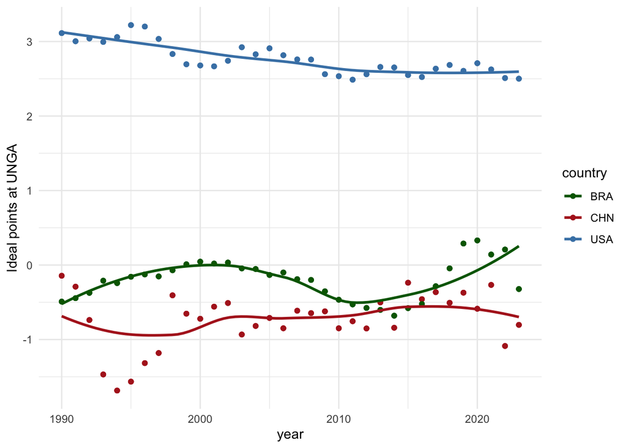

Evolution of UNGA ideal points for the United States, Brazil, and China over time. Note: Unit = UNGA ideal-point score (Bailey et al. scale). Time window = 1990-2022 annual series. Treatment definition = Treatment indicator equals 1 from 2009 onward, when China becomes Brazil’s top export destination displacing the USA, and 0 before 2009.

Having established that it is mostly Brazil moving around rather than China, we can use as our main variable the absolute distance between Brazil’s and China’s ideal points, with the understanding that, apart from the beginning of the nineties, Brazil is almost always closer to the center than China and that Brazil is the one moving around.

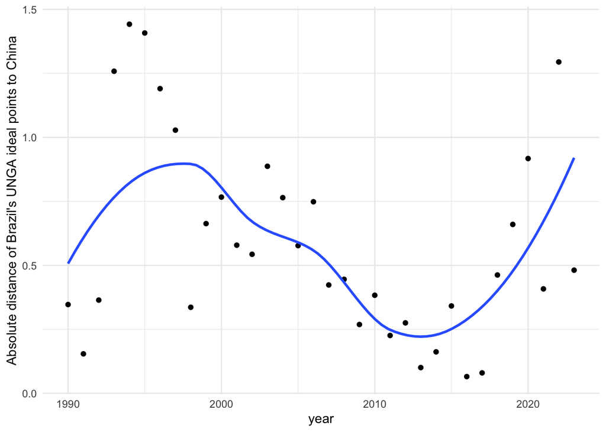

Absolute distance between Brazil and China in UNGA ideal points over time. Note: Unit = absolute UNGA ideal-point distance to China (points). Time window = 1990-2022 annual series. Treatment definition = Treatment indicator equals 1 from 2009 onward, when China becomes Brazil’s top export destination displacing the USA, and 0 before 2009.

Figure @ref(fig:plot-brazil-linear) isolates the Brazilian series used in the SDiD specification and overlays separate linear fits before and after 2009. The raw points show a lower post-2009 trajectory, but not a clean one-year break. This is exactly why the causal interpretation below relies on the SDiD counterfactual and on a post-treatment average, rather than on visual inspection of an abrupt discontinuity.

[figure not shown]

Brazil-China distance in UNGA ideal points. Points show raw annual absolute distances from the paper’s analytic dataset. The blue and orange lines are separate OLS fits estimated for the pre-2009 and post-2009 periods. The vertical dashed line marks 2009, when China became Brazil’s top trade partner. This figure is descriptive and should not be read as a causal estimate. Note: Unit = absolute UNGA ideal-point distance to China (points). Time window = 1997-2016 annual Brazil series from synth_data. Treatment definition = Treatment indicator equals 1 from 2009 onward, when China becomes Brazil’s top export destination displacing the USA, and 0 before 2009.

The question one wonders after seeing the graphs is: why was Brazil getting closer over time? The main hypothesis discussed in the literature is the gravitational pull of the Chinese economy, as indicated by the percentage of Brazil’s exports that went to China during the considered period. Figure @ref(fig:plot-trade) shows that around the year 2000, the percentage of exports destined for China increased at a roughly constant rate, exhibiting a steep variation that does not exactly align with the evolution of political alignment presented earlier, although there is some positive correlation with the evolution of political alignment shown in Figure @ref(fig:plot-unga2).

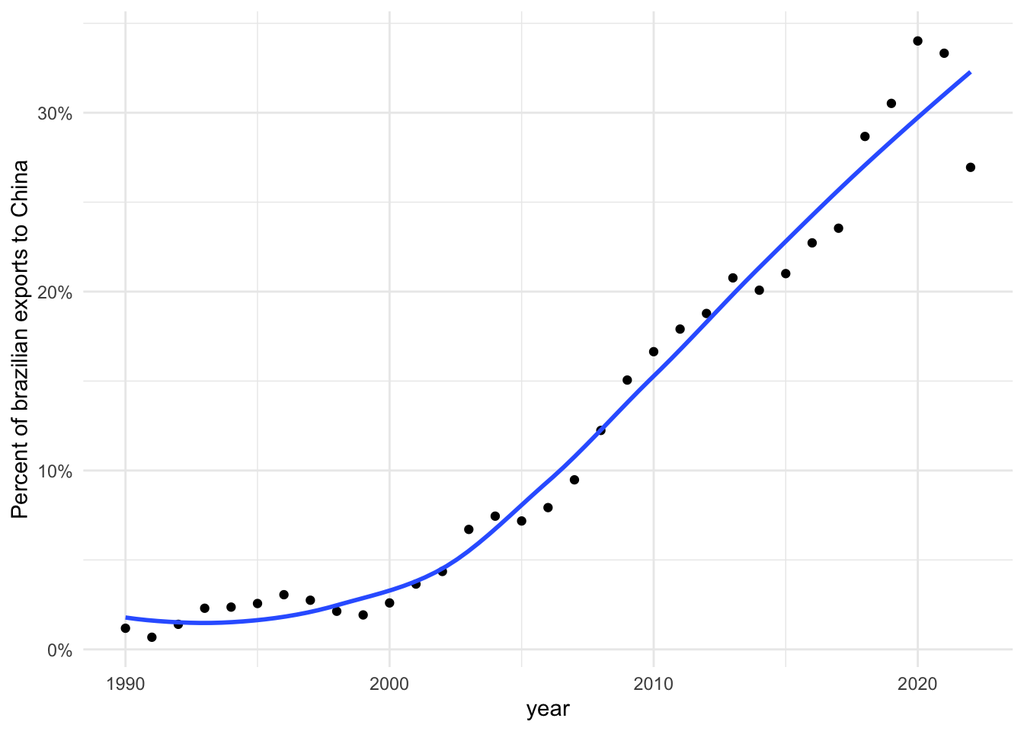

Share of Brazil’s exports destined for China over time. Note: Unit = share of Brazil’s exports to China (percent). Time window = 1990-2022 annual series. Treatment definition = Treatment indicator equals 1 from 2009 onward, when China becomes Brazil’s top export destination displacing the USA, and 0 before 2009.

# Empirical Results

Figure @ref(fig:plot-sdid) presents the evolution of political alignment between Brazil and China at the UNGA and among a donor pool of countries before and after China became Brazil’s main trade partner. The counterfactual estimate from the donor pool allows us to estimate the average causal effect of the treatment on the similarity of votes at UNGA over the post-2009 period. The estimate is -0.26 points, which means that becoming the main trade partner is associated with an average decrease of 0.26 points in the absolute distance between the ideal points of Brazil and China after 2009, relative to the synthetic counterfactual. Relative to Brazil’s pre-treatment mean distance (0.647), this corresponds to a 40.8% reduction. The point estimate is -0.26 with a 95% CI of (-0.51, -0.02) and p-value 0.032 under placebo-based inference. The estimate should not be interpreted as saying that Brazil’s ideal-point distance fell by 0.26 points in 2009 itself. It summarizes the post-treatment gap, consistent with a mechanism in which a salient rank reversal opens a window for gradual diplomatic adjustment. To put the magnitude in perspective, the estimated reduction of 0.26 ideal-point units can be compared with other known drivers of UNGA alignment. He, Zheng, and Chen (2025) find that Chinese arms exports shift recipients’ voting alignment toward China (2SLS), and Lektzian and Biglaiser (2023) estimate that the combination of US foreign aid and economic sanctions shifts bilateral voting patterns at the UNGA. Our estimate of 0.26 points from a single trade rank reversal suggests that discrete status milestones can produce alignment shifts on par with material policy instruments that the literature has identified as consequential.

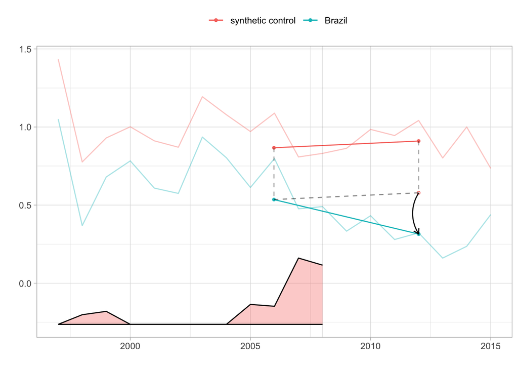

SDiD fit for Brazil and synthetic control with time weights. Note: Unit = absolute UNGA ideal-point distance to China (points). Standard error = placebo-based (reported in SDiD tables, not plotted here). Time window = pre-treatment and post-treatment years shown in the plot (treatment in 2009). Treatment definition = Treatment indicator equals 1 from 2009 onward, when China becomes Brazil’s top export destination displacing the USA, and 0 before 2009.

In Figure @ref(fig:plot-parallel), we plot the results for Brazil, along with the top 10 controls, filtered by weight size. As we can see from the graph, no other country displays behavior similar to Brazil’s, which lends credibility to the estimation of the causal effect[^2].

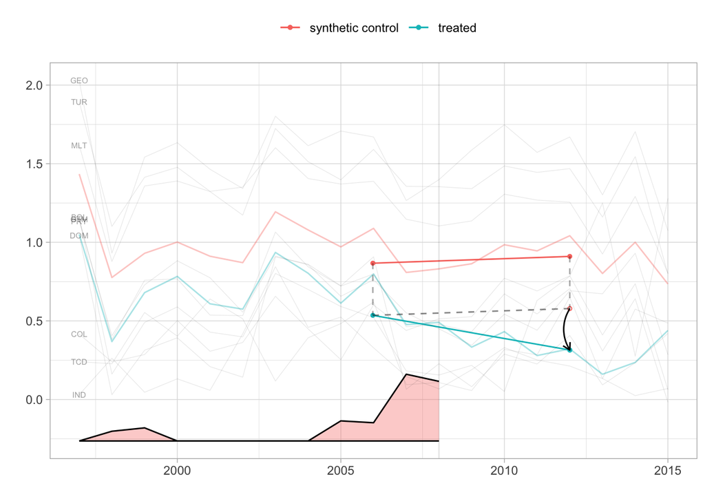

Top 10 donor controls by SDiD weight in the Brazilian specification. Note: Unit = country trajectories in absolute UNGA ideal-point distance; donor weights are unitless and sum to 1. Time window = pre-treatment and post-treatment years shown in the plot (treatment in 2009). Treatment definition = Treatment indicator equals 1 from 2009 onward, when China becomes Brazil’s top export destination displacing the USA, and 0 before 2009.

# Robustness Checks

The target estimand of the SDiD estimator is the average treatment effect on the treated for the period post-treatment, whose weights are different from zero. This means that, in theory, it may be capturing the effect of other treatments that happened at a prior or later time. The main argument of the paper is that there is a distinctive quality in becoming the number one trade partner. If that is the case, then we should not find any effect when China became the second (in 2003, after overtaking Argentina and again in 2005, after briefly losing the second spot to Argentina in 2004), nor a few years after being the top one for a while.

Note: Unit = ATT in absolute UNGA ideal-point distance to China (points). Standard error = placebo-based (95 percent CI = estimate $\pm$ 1.96 $\times$ SE). Time window = main model uses treatment in 2009; pre-treatment placebos set pseudo-treatment at 2003 and 2005 with sample truncated at 2008; late-break falsification sets pseudo-treatment at 2012. Treatment definition = main model applies the treatment definition at 2009; placebo models redefine treatment at the pseudo-treatment year.

A potential confounder is the Lula da Silva presidency (2003–2010), which pursued an explicit “South-South” foreign policy reorientation. However, Lula took office in 2003—six years before the treatment. If his ideology were driving alignment with China, the pre-treatment placebos at 2003 and 2005 should show significant effects; they do not. Moreover, the cross-country analysis (Section 7) shows that the effect is not specific to Brazil or to any single leader, as it appears across countries with different political systems and leadership ideologies. The staggered treatment timing across countries rules out any single-country political confounder.

A potential concern is whether the estimated effect reflects the discrete change in status by the rank reversal or simply a non-linear function of trade growth. Three pieces of evidence address this concern. First, our SDiD specification includes the share of trade with China and the share of trade with the United States as time-varying covariates, absorbing the linear effect of trade accumulation on alignment. Second, the placebo tests at 2003 and 2005 are directly informative: in both years, Brazil’s trade with China was growing rapidly – China overtook Argentina to become Brazil’s second-largest partner in 2003 – yet neither placebo produces a significant effect. If alignment responded smoothly to trade growth, these years of steep increases should show comparable shifts; they do not. Third, the cross-country analysis exploits staggered treatment timing: different countries reached the rank reversal at different trade-share levels and in different years, providing variation that separates the rank effect from any single trade trajectory[^3]. Together, these results support the interpretation that the status change itself – not the underlying trade growth – drives the observed alignment shift.

## Salience in the media

If the salience channel is relevant, there should be concrete evidence in Brazilian media coverage. To test this, we collected all headlines, stories, op-eds, and editorials mentioning “China” in Folha de São Paulo, Brazil’s widest-circulation newspaper (Folha de S.Paulo 2016), from 2000 to 2014. Among 48,029 pieces, we identified 14,589 with “China” (or variants like “Chinese”) in the headline, quantifying the evolution of China’s salience in national discourse.

The stories encompass a wide range of themes, including sports, natural disasters, politics, economics, science, and more. However, over time, news pieces about China have increasingly reflected its growing relevance as Brazil’s largest trade partner since 2009.

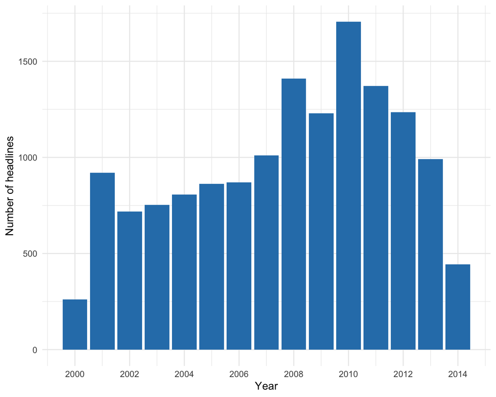

Number of Folha de Sao Paulo headlines mentioning China by year. Note: Unit = count of headlines. Standard error = not applicable. Cluster = not applicable. Time window = 2000-2014 annual series. Treatment definition = Treatment indicator equals 1 from 2009 onward, when China becomes Brazil’s top export destination displacing the USA, and 0 before 2009.

However, it is possible that China’s rise in the news is due to events unrelated to trade, such as increased tensions with the US or the Beijing Olympics. To clarify whether trade-related news became more salient after 2009, we utilized the OpenAI API for ChatGPT, model gpt-4.1-mini, created on April 10, 2025, to categorize the news—see the appendix for details—into 9 categories. This step allows us to assess precisely how trade-focused news evolved over time.

This distinction is crucial because volume alone could reflect any China‑related event. What matters is the substance of what journalists discussed. To track this, Figure @ref(fig:plot-folha2) plots the share of trade-economy pieces in all China headlines. The peak is in 2004, when there was less news about China in total and it was the year that Brazil recognized China as a market economy at the WTO (14% of all trade-related stories that year), with mostly negative headlines. Manual reading of the trade news pieces at the time shows that a plurality of them are about soy import barriers put in place by China (38% of all trade-related stories that year). So, although it was a highly salient year, it was not the type of salience that would trigger pressure on foreign policy from the business community toward China.

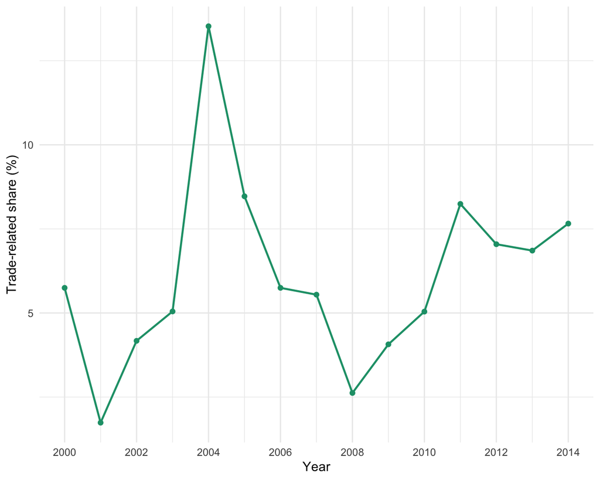

Share of trade-related items among all China headlines per year. Note: Unit = share of trade-related China headlines (percent). Standard error = not applicable. Cluster = not applicable. Time window = 2000-2014 annual series. Treatment definition = Treatment indicator equals 1 from 2009 onward, when China becomes Brazil’s top export destination displacing the USA, and 0 before 2009.

A closer look at the evolving themes further illustrates this shift. Up to 2006, the main China-related coverage focused on health issues, North Korea and nuclear topics, as well as certain sports themes (“seleção brasileira”). By 2009, those subjects remained, but news about Asia, the China and Hong Kong stock markets, and, centrally, Brazilian company Vale do Rio Doce’s exports to China—closely linked with the Dollar and Brazilian trade—became prominent. This evidence is central to our proposed mechanism, as it illustrates the qualitative transformation in the economic relationship between Brazilian companies, the broader economy, and China. It is helpful to zoom in and compare 2008 with 2009 for further clarity.

A lexical snapshot emphasizes the qualitative break between years. By examining the most frequent trigrams, we gain insight into the changing content from year to year. Trigrams are strings of three tokens that help segment sentences into key phrases (Violos et al. 2018). In 2008, the most common three‑word bundles included ‘earthquake’, ‘Olympic torch’, and ‘bird flu’. In 2009, they shifted decisively to ‘record iron‑ore exports’, ‘Bovespa rises’, and ‘Brazil‑China trade hits record’—precisely the salience cues our theory predicts.

Headlines with “bate” (“reach”) illustrate the pattern: In 2009, headlines like “Agribusiness exports reach record high, with China as the main highlight” and “China hits record iron ore imports” repeatedly appeared, while in 2008, “bate” appeared only once in an agribusiness context[^4].

Political elite discourse mirrored the media. During his May 2009 visit to Beijing, President Lula opened a business seminar by noting that ‘China has become, in 2009, Brazil’s largest trading partner’ and immediately linked this milestone to a coincidence of positions in international forums (Presidência da República Federativa do Brasil 2009). Two years later, Deputy Aldo Rebelo reminded the Foreign‑Affairs Committee that China’s elevation to first place justified deeper legal cooperation (Câmara dos Deputados 2011).

A natural concern is whether the post-2009 increase in trade-related China coverage reflects the rank reversal specifically or is driven by confounding events – the 2008 global financial crisis, the post-Olympics China attention cycle, or general economic turbulence. To address this, Figure @ref(fig:plot-media-counterfactual) disaggregates all China headlines into broad categories: China-Brazil Trade, Chinese Economy, Diplomacy & Relations, and Non-economic (sports, health, disasters, etc.). If the media shift were driven by the financial crisis or post-Olympics attention, we would expect all economic categories – or non-economic categories – to show comparable increases. Instead, the data show that the sustained post-2009 growth is concentrated specifically in trade-related coverage: China-Brazil Trade headlines nearly tripled from 37 in 2008 to 113 in 2011, while non-economic coverage remained stable or declined after the 2008 Olympics spike. The Chinese Economy category also grew but tracked general global recovery rather than the bilateral trade milestone.

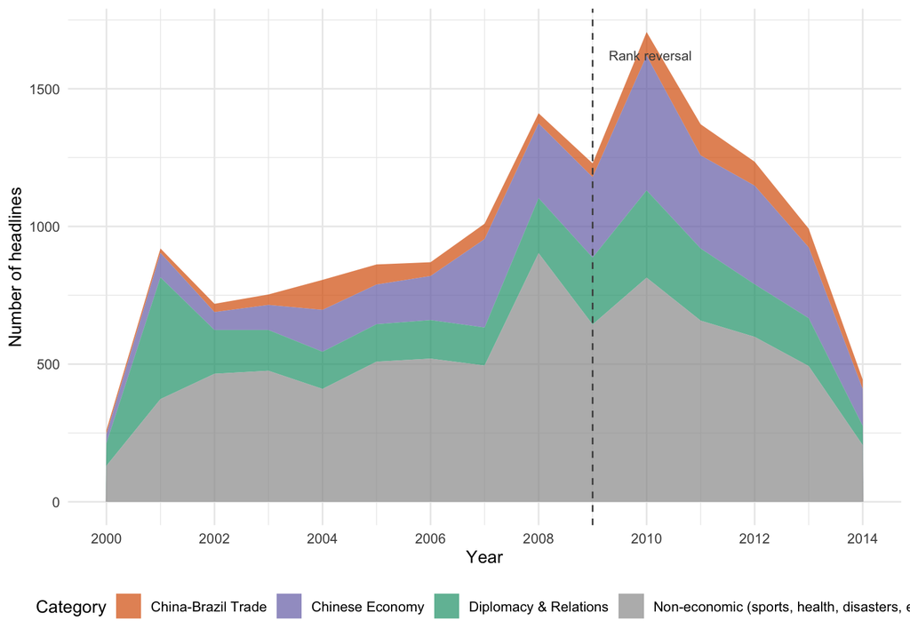

Media counterfactual: disaggregated China headlines in Folha de Sao Paulo by category, 2000-2014. The sustained post-2009 increase is concentrated in trade-related coverage. Note: Unit = count of headlines per category per year. Time window = 2000-2014 annual series. Treatment definition = Treatment indicator equals 1 from 2009 onward, when China becomes Brazil’s top export destination displacing the USA, and 0 before 2009.

# Cross-Country Evidence

The Brazilian case generated the theory and provided internally valid causal evidence via SDiD. However, it remains a single case, and we cannot rule out idiosyncratic confounders. We now test the generalizability of the status-salience theory using a cross-country design, which constitutes an independent out-of-sample test.

A natural question is whether the same effect occurs when China displaces the United States as the top trade partner in other countries. Our theory predicts effects specifically when an emerging power displaces the hegemon – not when China overtakes Belgium or Singapore. This distinction is theoretically motivated: the status shock is most salient when the displaced partner is the incumbent great power, whose position in a country’s trade hierarchy carries symbolic and geopolitical weight.

## Main result (fect IFE)

We estimate the ATT using the counterfactual estimator with interactive fixed effects (IFE) of Liu, Wang, and Xu (2024). The IFE model relaxes the strict parallel trends assumption by allowing for latent common factors with heterogeneous loadings, and cross-validation selects $r^* = 1$ factors. The overall ATT is -0.074 (bootstrap SE = 0.029, 95% CI [-0.131, -0.017], p = 0.011), indicating that when China holds the top trade partner position, countries move significantly closer to China in UNGA voting. Substantively, this corresponds to about 9.4% of the pre-treatment mean distance to China. For comparison, the cross-sectional standard deviation of UNGA distance to China across all countries in the panel is approximately 0.79 points, so the IFE estimate represents roughly one-tenth of a standard deviation – a modest but meaningful shift when considering that it is produced by a single symbolic milestone rather than a structural change in economic ties.

Note: Unit = ATT in absolute UNGA ideal-point distance to China (points). Standard error = bootstrap (fect) / analytical (C&S). Cluster = country level. Time window = panel covers 1990-2023. Treatment definition = Treatment indicator equals 1 in any year China is currently the top export destination; turns off if USA regains the position (switching treatment).

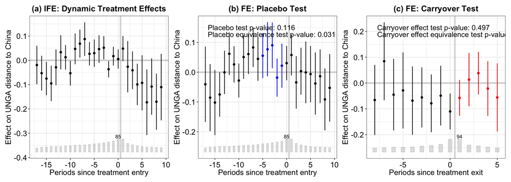

Diagnostic tests for the cross-country fect analysis (Liu, Wang & Xu 2024). (a) IFE dynamic treatment effects; (b) FE placebo test with placebo periods in blue; (c) FE carryover test with carryover periods in red. Note: Unit = ATT in absolute UNGA ideal-point distance to China (points). Standard error = bootstrap (500 replications). Time window = 1990-2023 panel. Treatment definition = Treatment indicator equals 1 in any year China is currently the top export destination; turns off if USA regains the position (switching treatment).

## Exit effects and treatment reversals

A distinctive advantage of the switching-treatment framework is the ability to estimate exit effects – what happens to UNGA alignment when the USA regains the top trade partner position and the treatment turns off. This provides a direct test of the salience mechanism: if the alignment shift is driven by the ongoing salience of China’s status as top partner, the effect should dissipate when that status is lost.

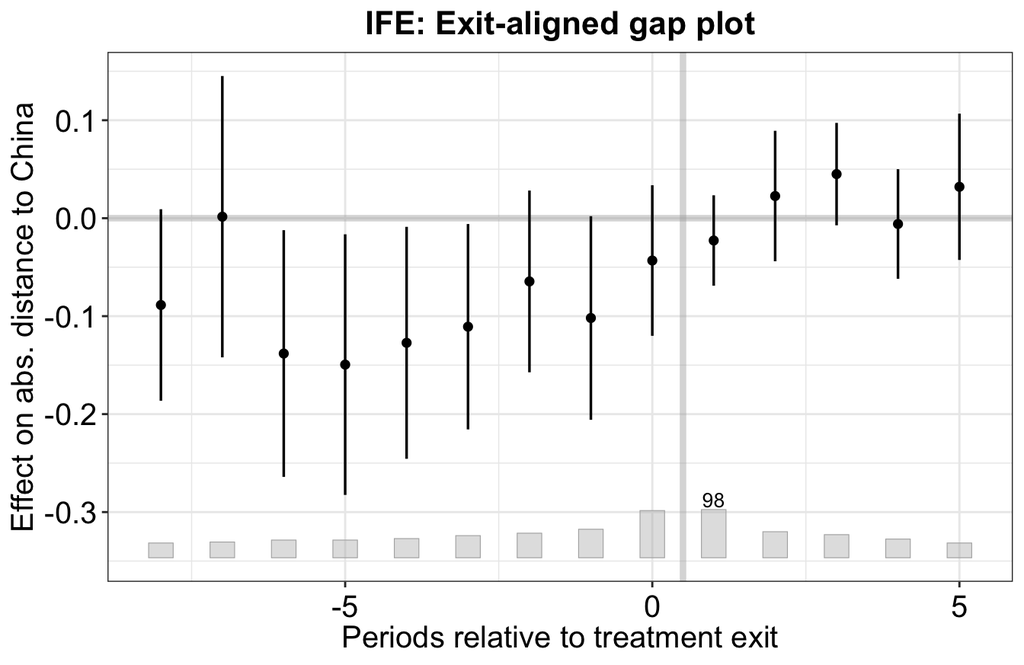

fect IFE: Exit-aligned gap plot showing what happens when the USA regains the top trade partner position. Note: Unit = ATT in absolute UNGA ideal-point distance to China (points). Standard error = bootstrap (500 replications). Time window = 1990-2023 panel. Treatment definition = Treatment indicator equals 1 in any year China is currently the top export destination; turns off if USA regains the position (switching treatment).

The exit-aligned gap plot shows that the treatment effect dissipates after the USA regains the top position – consistent with the carryover test results reported in Figure @ref(fig:plot-diagnostics)(c). This pattern is consistent with the salience mechanism (H4): unlike structural bandwagoning and coercion, which predict persistent effects regardless of current trade status, the salience channel predicts that the effect is tied to the cognitive category “China = top partner” and should fade when that category is disrupted. We note that interest-based and trade-dependence theories also predict reversible effects, so exit effects alone do not uniquely identify salience (see Section 7.4).

We complement the fect analysis with PanelMatch (Imai, Kim, and Wang 2023), which separately estimates the Average Treatment Effect on the Treated (ATT, switch-on) and the Average Treatment Reversal Effect on the Treated (ART, switch-off).

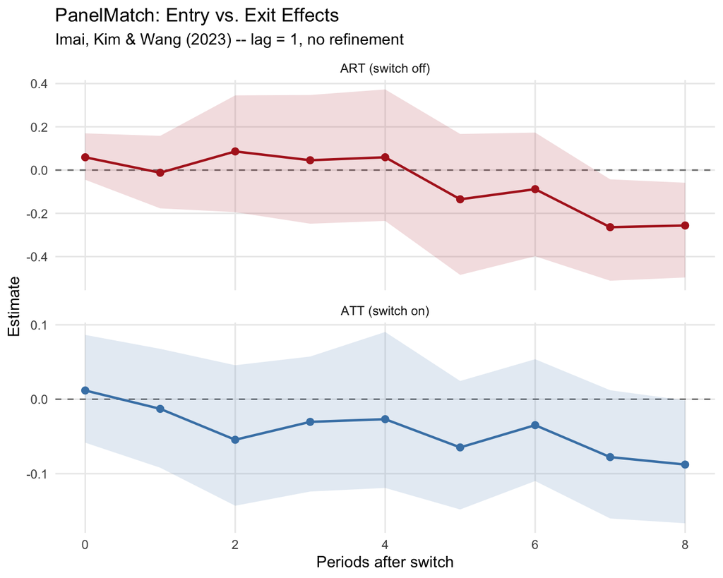

PanelMatch: Entry (ATT) and exit (ART) effects of China’s status as top trade partner. Note: Unit = ATT/ART in absolute UNGA ideal-point distance to China (points). Standard error = bootstrap (1000 iterations). Time window = 1990-2023 panel. Treatment definition = Treatment indicator equals 1 in any year China is currently the top export destination; turns off if USA regains the position (switching treatment).

The PanelMatch results are noisier than fect, as expected with matching-based inference on a small panel. The ATT estimates are small at lead 0 (0.012) but become progressively negative at longer leads, consistent with a gradual alignment effect. The ART at lead 0 is 0.059 (95% CI [-0.045, 0.170]), directionally consistent with countries moving away from China when the USA regains the top position. While the individual lead-level estimates are imprecise due to the small number of switching events, the overall pattern – negative entry effects that build over time and positive initial exit effects – is consistent with the fect results and supports a mechanism tied to current trade status.

## Raw data

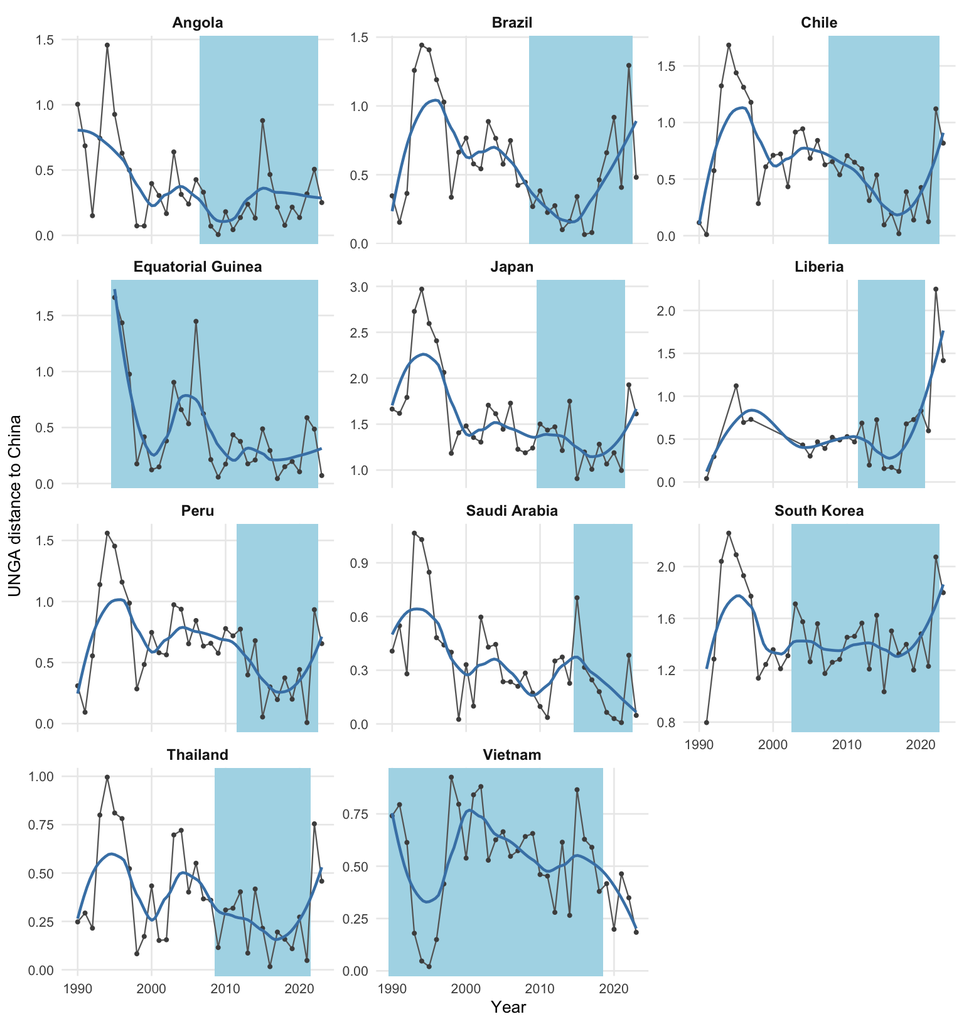

UNGA voting distance to China for treated countries where China displaced the USA. Note: Unit = absolute UNGA ideal-point distance to China (points). Time window = treated-country yearly series within 1990-2022; treatment year varies by country. Treatment definition = Treatment indicator equals 1 in any year China is currently the top export destination; turns off if USA regains the position (switching treatment).

The raw data reveal that most treated countries experienced a lower ideological distance to China over the post-reversal period, consistent with the estimated ATT, but the trajectories are not uniform one-year breaks. The raw trajectories also confirm the switching pattern: countries where the USA regains the top position show a partial rebound, consistent with the exit effects estimated in Figure @ref(fig:plot-fect-exit).

## Dynamic treatment effects and the temporality of the status effect

Figure @ref(fig:plot-diagnostics) already displays the dynamic treatment effects relative to treatment entry. The effect turns negative after the rank reversal, reaches its largest negative values in the first few years post-treatment, and then gradually attenuates. This temporal pattern is substantively important because it is more consistent with accumulated diplomatic adjustment than with an instantaneous and permanent step change.

A status-salience mechanism, by definition, operates through a cue – the rank reversal – that is most prominent when it first occurs. However, foreign-policy positions are sticky: diplomats inherit previous votes, governments avoid abrupt reversals on high-profile issues, and reputational costs make immediate across-the-board switching unlikely. The theory therefore predicts an immediate attention shock but a policy response that can build over several years. Over time, the novelty fades: the new status quo becomes normalized, media attention moves to other stories, and policymakers’ consideration sets shift. The gradual attenuation is therefore theoretically predicted: unlike mechanisms that depend on durable structural changes (such as trade volume or economic dependence), the salience channel should produce a temporary effect that dissipates as the cue loses its informational novelty. This is what the estimates suggest.

The exit-aligned analysis provides a more direct test of temporality than the entry-aligned event study alone. The Brazilian case already hinted at the attenuation pattern, as the raw UNGA distance data showed a rebound after 2015, but the single-case design could not distinguish the rebound from idiosyncratic noise (e.g., the transition from Rousseff to Temer after an impeachment). The cross-country exit effects confirm that the rebound is systematic across treated countries, not a Brazil-specific artifact[^5].

## Alternative Explanations

We systematically consider the most plausible alternative explanations and their empirically distinguishable predictions:

| Alternative | Key prediction | Exit effects predicted? | Discriminating evidence |
| --- | --- | --- | --- |
| Structural bandwagoning | Persistent alignment shift | No – predicts persistence | Entry-aligned attenuation + exit effects show dissipation (H4) |
| Chinese coercion | Effect for any displaced partner | No – leverage persists | Only hegemon displacement produces effect (H2) |
| Interest-based (trade dependence) | Effect tracks current trade dependence | Yes – if trade reverses | Discrete effect beyond trade-share covariates; but cannot fully rule out |
| Gradual trade growth | Monotonically increasing effect | Yes – if trade declines | Carmody, Dasandi, and Mikhaylov (2020) show continuous trade growth produces hedging, not alignment |
| Ideologically aligned leader | Step-change at leader inauguration | Possible | DPI controls; Dreher and Jensen (2013) find leader change pushes votes toward the US |
| 2008 financial crisis | Temporal confound in 2008–2009 | No | Staggered treatment: rank reversals in other years also produce effect; IFE absorbs common shocks |

The exit effects rule out structural bandwagoning and coercion, both of which predict persistent effects. However, interest-based and trade-dependence theories also predict reversible effects: if the interests themselves reverse when the USA regains the top position, alignment should revert. The exit effects therefore narrow the set of plausible mechanisms to those consistent with reversibility (salience, interest-based, trade-dependence) but do not uniquely identify salience. The additional evidence for salience comes from the media analysis (Section 5): the rank reversal triggers a categorical reclassification in media coverage that is not reducible to gradual trade growth.

We do not claim to have ruled out all alternatives. What we show is that the empirical signature – a discrete, hegemon-specific effect that dissipates upon exit, accompanied by a media-coverage shift – is most consistent with the status-salience mechanism and least consistent with the leading alternatives. Interest-based theories remain a plausible complementary explanation.

# Conclusion

We have proposed a theory that status change induced by trade rank reversal, when China surpassed the US as the main trade partner of a country, can produce foreign policy realignment. We found initial support for this effect when China overtook the US as Brazil’s leading trade partner. The evidence is consistent with the idea that the symbolic significance of overtaking a historic trade partner opened a window for gradual diplomatic adjustment, beyond changes in trade volume. The cross-country regressions confirm the original finding, although with a smaller magnitude, which is expected, since Brazil is the most likely case. At the same time, evidence on the underlying salience mechanism is correlational and suggestive rather than causally identified.

Overall, the results suggest that we should look beyond the increasing trade ties between countries, as has been done in the literature so far (Yan and Zhou 2021; Flores-Macías and Kreps 2013; Reilly 2013), and also focus on qualitative shifts in the public perception of a trade partner’s status.

The results have broad implications for the literature on status. While it has focused on explaining how the search for status may trigger conflicts, it has overlooked robust empirical evidence that an increase in status changes the behavior of another country. Thus, contrary to Mercer (2017), who argued that prestige is illusory, we have shown that it matters in a realm important for a country like China, namely, voting in the UNGA.

Our study has some limitations that future research could investigate further. The cross-country analysis confirms that the status effect generalizes among countries where China displaced the United States, and our preliminary comparison with non-US displacement events (Section 7.2) provides an initial probe of the hegemon moderation hypothesis. However, the number of non-US cases remains small and heterogeneous, limiting the power of this comparison. Furthermore, we lack cross-country media data to verify whether the salience mechanism operates in the same way outside Brazil.

Secondly, the proposed mechanism has only indirect evidence. We have shown that newspaper coverage of trade ties with China shifted when it surpassed the US as the primary trade partner. However, we lack evidence on how business lobbies responded to it, and we do not have systematic data on the public or political elites. Qualitative studies with political and economic elites could attempt to recover their thinking at the time, for instance. Laboratory experiments could be conducted to provide evidence on the psychological and cognitive mechanisms underlying status based on a change in the rank of a partner.

Our findings also carry practical implications. From the perspective of US policymakers, the results suggest that symbolic milestones in trade hierarchies deserve attention alongside aggregate trade volumes. If losing the top trade partner position initiates a post-reversal process of diplomatic realignment, then monitoring and responding to these threshold crossings – rather than focusing solely on trade balances – may be a more effective strategy for maintaining influence. More broadly, the finding that alignment effects dissipate when the USA regains the top position implies that trade-status losses are not irreversible, and that targeted trade engagement could mitigate diplomatic realignment.

Despite these limitations, our study is the first to provide systematic evidence for trade-status effects in international relations. By highlighting trade-status salience, this study opens up new avenues for understanding how discrete milestones in economic ties can reshape international alignments and invites extensions to other domains (e.g., FDI, foreign aid, loans) and regions.

# References

Aiyar, Shekhar, Davide Malacrino, and Andrea F. Presbitero. 2024. “Investing in Friends: The Role of Geopolitical Alignment in FDI Flows.” *European Journal of Political Economy* 83 (June): 102508. https://doi.org/10.1016/j.ejpoleco.2024.102508.

Anagol, Santosh, and Thomas Fujiwara. 2016. “The Runner-up Effect.” *Journal of Political Economy* 124 (4): 927–91.

Angrist, Joshua D., and Jörn-Steffen Pischke. 2009. *Mostly Harmless Econometrics: An Empiricist’s Companion*. Princeton: Princeton University Press.

Arkhangelsky, Dmitry, Susan Athey, David A. Hirshberg, Guido W. Imbens, and Stefan Wager. 2021. “Synthetic Difference-in-Differences.” *American Economic Review* 111 (12): 4088–118. https://doi.org/10.1257/aer.20190159.

Baekgaard, Martin, Julian Christensen, Casper Mondrup Dahlmann, Asbjørn Mathiasen, and Niels Bjørn Grund Petersen. 2019. “The Role of Evidence in Politics: Motivated Reasoning and Persuasion Among Politicians.” *British Journal of Political Science* 49 (3): 1117–40. https://doi.org/10.1017/S0007123417000084.

Bai, Jushan. 2009. “Panel Data Models with Interactive Fixed Effects.” *Econometrica* 77 (4): 1229–79. https://doi.org/10.3982/ECTA6135.

Bailey, Michael A, Anton Strezhnev, and Erik Voeten. 2017. “Estimating Dynamic State Preferences from United Nations Voting Data.” *Journal of Conflict Resolution* 61 (2): 430–56.

Bastardoz, Nicolas, Michael J. Matthews, Gwendolin B. Sajons, Tyler Ransom, Thomas K. Kelemen, and Samuel H. Matthews. 2023. “Instrumental Variables Estimation: Assumptions, Pitfalls, and Guidelines.” *The Leadership Quarterly* 34 (1): 101673. https://doi.org/10.1016/j.leaqua.2022.101673.

BBC News. 2021. “China Overtakes US as EU’s Biggest Trading Partner.” https://www.bbc.com/news/business-56093378.

Blackwell, Matthew, and Adam N Glynn. 2018. “How to Make Causal Inferences with Time-Series Cross-Sectional Data Under Selection on Observables.” *American Political Science Review* 112 (4): 1067–82.

Borchert, Ingo, Mario Larch, Serge Shikher, and Yoto V Yotov. 2021. “The International Trade and Production Database for Estimation (ITPD-E).” *International Economics* 166: 140–66.

Bordalo, Pedro, Nicola Gennaioli, and Andrei Shleifer. 2022. “Salience.” *Annual Review of Economics* 14: 521–44. https://doi.org/10.1146/annurev-economics-051520-011616.

Callaway, Brantly, and Pedro H. C. Sant’Anna. 2021. “Difference-in-Differences with Multiple Time Periods.” *Journal of Econometrics* 225 (2): 200–230. https://doi.org/10.1016/j.jeconom.2020.12.001.

Câmara dos Deputados. 2011. “Comissão Aprova Acordo de Direitos Civil e Comercial Entre Brasil e China.” https://www.camara.leg.br/noticias/222695-comissao-aprova-acordo-de-direitos-civil-e-comercial-entre-brasil-e-china/.

Carmody, Pádraig, Niheer Dasandi, and Slava Jankin Mikhaylov. 2020. “Power Plays and Balancing Acts: A New Mapping of the African Geoeconomic Landscape in Response to the Rise of China.” *Political Studies* 68 (4): 852–70. https://doi.org/10.1177/0032321719882791.

Chen, Qin, and Yi Zhou. 2021. “Whose Trade Follows the Flag? Institutional Constraints and Economic Responses to Bilateral Relations.” *Journal of Peace Research* 58 (6): 1207–23. https://doi.org/10.1177/0022343321992825.

Chiu, Albert, Xingchen Lan, Ziyi Liu, and Yiqing Xu. 2025. “Causal Panel Analysis Under Parallel Trends: Lessons from a Large Reanalysis Study.” *American Political Science Review*. https://doi.org/10.1017/S0003055424001035.

Conlon, John J. 2025. “Attention, Neglect, and Persuasion.” https://johnjconlon17.github.io/website/conlon_attention_persuasion.pdf.

Coutinho, Yuri Bravo, and Júlio César Cossio Rodriguez. 2024. “Chinese Double Effect on Brazilian Foreign Policy (2003-2018).” *Contexto Internacional* 46 (2): e20230014. https://doi.org/10.1590/s0102-8529.20244602e20230014.

Cruz, Cesi, Philip Keefer, and Carlos Scartascini. 2021. “Database of Political Institutions 2020.” *Inter-American Development Bank Research Department*. https://doi.org/10.18235/0003049.

Dafoe, Allan, Jonathan Renshon, and Paul Huth. 2014. “Reputation and Status as Motives for War.” *Annual Review of Political Science* 17 (1): 371–93. https://doi.org/10.1146/annurev-polisci-071112-213421.

Dreher, Axel, and Nathan M. Jensen. 2013. “Country or Leader? Political Change and UN General Assembly Voting.” *European Journal of Political Economy* 29: 183–96. https://doi.org/10.1016/j.ejpoleco.2012.10.001.

Duque, Marina G. 2018. “Recognizing International Status: A Relational Approach.” *International Studies Quarterly* 62 (3): 577–92. https://doi.org/10.1093/isq/sqy001.

Edwards, George C., and B. Dan Wood. 1999. “Who Influences Whom? The President, Congress, and the Media.” *American Political Science Review* 93 (2): 327–44. https://doi.org/10.2307/2585399.

Enke, Benjamin. 2024. “The Cognitive Turn in Behavioral Economics.”

Enke, Benjamin, and Florian Zimmermann. 2017. “Correlation Neglect in Belief Formation.” *The Review of Economic Studies*, December. https://doi.org/10.1093/restud/rdx081.

Fearon, James D. 1994. “Domestic Political Audiences and the Escalation of International Disputes.” *American Political Science Review* 88 (3): 577–92. https://doi.org/10.2307/2944796.

Flores-Macías, Gustavo A., and Sarah E. Kreps. 2013. “The Foreign Policy Consequences of Trade: China’s Commercial Relations with Africa and Latin America, 1992–2006.” *The Journal of Politics* 75 (2): 357–71. https://doi.org/10.1017/S0022381613000066.

Folha de S.Paulo. 2016. “Alcance total dos jornais.” https://arte.folha.uol.com.br/graficos/QcVNh/.

Folke, Olle, Torsten Persson, and Johanna Rickne. 2016. “The Primary Effect: Preference Votes and Political Promotions.” *American Political Science Review* 110 (3): 559–78.

Frankel, Jeffrey, and George Saravelos. 2012. “Can Leading Indicators Assess Country Vulnerability? Evidence from the 2008–09 Global Financial Crisis.” *Journal of International Economics* 87 (2): 216–31.

Fuchs, Andreas, and Nils-Hendrik Klann. 2013. “Paying a Visit: The Dalai Lama Effect on International Trade.” *Journal of International Economics* 91 (1): 164–77. https://doi.org/10.1016/j.jinteco.2013.04.007.

Fujiwara, Thomas, and Carlos Sanz. 2020. “Rank Effects in Bargaining: Evidence from Government Formation.” *Review of Economic Studies* 87 (3): 1261–95. https://doi.org/10.1093/restud/rdz044.

Garcia-Herrero, Alicia, Thibault Storella, and Pekka Weil. 2024. “China’s Influence at the United Nations: Words and Deeds.” Working Paper 19/2024. Bruegel.

Gelman, Andrew, and Guido Imbens. 2019. “Why High-Order Polynomials Should Not Be Used in Regression Discontinuity Designs.” *Journal of Business & Economic Statistics* 37 (3): 447–56. https://doi.org/10.1080/07350015.2017.1366909.

Götz, Elias. 2021. “Status Matters in World Politics.” *International Studies Review* 23 (1): 228–47. https://doi.org/10.1093/isr/viaa046.

Graeber, Thomas, Christopher Roth, and Marco Sammon. 2025. “Coarse Categories in a Complex World.” University of Bonn and University of Cologne, Germany.

Granzier, Riako, Vincent Pons, and Clemence Tricaud. 2023. “Coordination and Bandwagon Effects: How Past Rankings Shape the Behavior of Voters and Candidates.” *American Economic Journal: Applied Economics* 15 (4): 177–217. https://doi.org/10.1257/app.20210840.

Gurevich, Tamara, and Peter Herman. 2018. “The Dynamic Gravity Dataset: 1948–2016.” *USITC Working Paper, 2018–02–A*.

Haibin, Niu. 2010. “Emerging Global Partnership: Brazil and China.” *Revista Brasileira de Polı́tica Internacional* 53: 183–92.

He, Xiaoyu, Yawen Zheng, and Yiwen Chen. 2025. “Weapons and Influence: Unpacking the Impact of Chinese Arms Exports on the UNGA Voting Alignment.” *European Journal of Political Economy* 87: 102666. https://doi.org/10.1016/j.ejpoleco.2025.102666.

Hirshberg, David, and Sylvia Klosin. 2024. “Synthetic Differences-in-Differences with Covariates.” https://klosins.github.io/Hirshberg_Klosin_SDIDC.pdf.

Imai, Kosuke, and In Song Kim. 2019. “When Should We Use Unit Fixed Effects Regression Models for Causal Inference with Longitudinal Data?” *American Journal of Political Science* 63 (2): 467–90. https://doi.org/10.1111/ajps.12417.

———. 2021. “On the Use of Two-Way Fixed Effects Regression Models for Causal Inference with Panel Data.” *Political Analysis* 29 (3): 405–15.

Imai, Kosuke, In Song Kim, and Erik H. Wang. 2023. “Matching Methods for Causal Inference with Time-Series Cross-Sectional Data.” *American Journal of Political Science* 67 (3): 587–605. https://doi.org/10.1111/ajps.12685.

Jabarian, Brian, and Elia Sartori. 2024. “Critical Thinking and Storytelling Contexts.” https://doi.org/10.2139/ssrn.4991780.

Kastner, Scott L., and Margaret M. Pearson. 2021. “Exploring the Parameters of China’s Economic Influence.” *Studies in Comparative International Development* 56 (1): 18–44. https://doi.org/10.1007/s12116-021-09318-9.

Lal, Apoorva, Mackenzie Lockhart, Yiqing Xu, and Ziwen Zu. 2024. “How Much Should We Trust Instrumental Variable Estimates in Political Science? Practical Advice Based on 67 Replicated Studies.” *Political Analysis* 32 (4): 521–40.

Lektzian, David, and Glen Biglaiser. 2023. “Sanctions, Aid, and Voting Patterns in the United Nations General Assembly.” *International Interactions* 49 (1): 59–85. https://doi.org/10.1080/03050629.2023.2155151.

Liu, Licheng, Ye Wang, and Yiqing Xu. 2024. “A Practical Guide to Counterfactual Estimators for Causal Inference with Time-Series Cross-Sectional Data.” *American Journal of Political Science* 68 (1): 160–76.

MacDonald, Paul K., and Joseph M. Parent. 2021. “The Status of Status in World Politics.” *World Politics* 73 (2): 358–91. https://doi.org/10.1017/s0043887120000301.

MacKinnon, James G., and Matthew D. Webb. 2018. “The Wild Bootstrap for Few (Treated) Clusters.” *The Econometrics Journal* 21 (2): 114–35. https://doi.org/10.1111/ectj.12107.

Mellon, Jonathan. 2021. “Rain, Rain, Go Away: 194 Potential Exclusion-Restriction Violations for Studies Using Weather as an Instrumental Variable.” *American Journal of Political Science*.

Mercer, Jonathan. 2017. “The Illusion of International Prestige.” *International Security* 41 (4): 133–68. https://doi.org/10.1162/isec_a_00276.

Miller, Jennifer L., Jacob Cramer, Thomas J. Volgy, Paul Bezerra, Megan Hauser, and Christina Sciabarra. 2015. “Norms, Behavioral Compliance, and Status Attribution in International Politics.” *International Interactions* 41 (5): 779–804. https://doi.org/10.1080/03050629.2015.1037709.

Mintz, Alex. 2004. “How Do Leaders Make Decisions? A Poliheuristic Perspective.” *Journal of Conflict Resolution* 48 (1): 3–13.

———. 2005. “Applied Decision Analysis: Utilizing Poliheuristic Theory to Explain and Predict Foreign Policy and National Security Decisions.” *International Studies Perspectives* 6 (1): 94–98. https://doi.org/10.1111/j.1528-3577.2005.00195.x.

Mintz, Alex, and Nehemia Geva. 1997. “The Poliheuristic Theory of Foreign Policy Decisionmaking.” In *Decisionmaking on War and Peace: The Cognitive–Rational Debate*, edited by Nehemia Geva and Alex Mintz, 81–101. Boulder, CO: Lynne Rienner.

Morgan, Pippa. 2019. “Can China’s Economic Statecraft Win Soft Power in Africa? Unpacking Trade, Investment and Aid.” *Journal of Chinese Political Science* 24 (3): 387–409. https://doi.org/10.1007/s11366-018-09592-w.

Mourón, Fernando, and Francisco Urdinez. 2014. “A Comparative Analysis of Brazil’s Foreign Policy Drivers Towards the USA: Comment on Amorim Neto (2011).” *Brazilian Political Science Review* 8 (2): 94–115. https://doi.org/10.1590/1981-38212014000100013.

Müller, Karsten, Chenzi Xu, Mohamed Lehbib, and Ziliang Chen. 2025. “The Global Macro Database: A New International Macroeconomic Dataset.” Working {{Paper}} 33714. Working Paper Series. National Bureau of Economic Research. https://doi.org/10.3386/w33714.

Neto, Octavio Amorim. 2011. *De Dutra a Lula: A Condução e Os Determinantes Da Polı́tica Externa Brasileira*. Elsevier Brasil.

Neto, Octavio Amorim, and Andrés Malamud. 2015. “What Determines Foreign Policy in Latin America? Systemic Versus Domestic Factors in Argentina, Brazil, and Mexico, 1946–2008.” *Latin American Politics and Society* 57 (4): 1–27.

Parlar Dal, Emel. 2019. “Status Competition and Rising Powers in Global Governance: An Introduction.” *Contemporary Politics* 25 (5): 499–511. https://doi.org/10.1080/13569775.2019.1627767.

Pemstein, Daniel, Kyle L. Marquardt, Eitan Tzelgov, Yi-ting Wang, Juraj Medzihorsky, Joshua Krusell, Farhad Miri, and Johannes von Römer. 2024. “The V-Dem Measurement Model: Latent Variable Analysis for Cross-National and Cross-Temporal Expert-Coded Data.” *V-Dem Working Paper*, no. 21.

Potrafke, Niklas. 2009. “Does Government Ideology Influence Political Alignment with the US? An Empirical Analysis of Voting in the UN General Assembly.” *The Review of International Organizations* 4 (3): 245–68.

Presidência da República Federativa do Brasil. 2009. “Discurso Do Presidente Da República Luiz Inácio Lula Da Silva Por Ocasião Do Seminário Brasil-China: Novas Oportunidades Para a Parceria Estratégica — Pequim, 19 de Maio de 2009.” https://www.gov.br/mre/pt-br/centrais-de-conteudo/publicacoes/discursos-artigos-e-entrevistas/presidente-da-republica/presidente-da-republica-federativa-do-brasil-discursos/luiz-inacio-lula-da-silva-2003-2007/discurso-do-presidente-da-republica-luiz-inacio-lula-da-silva-por-ocasiao-do-seminario-brasil-china-novas-oportunidades-para-a-parceria-estrategica-pequim-19-de-maio-de-2009.

Reilly, James. 2013. “China’s Economic Statecraft: Turning Wealth into Power.” Analysis. Sydney: Lowy Institute for International Policy. https://www.lowyinstitute.org/sites/default/files/reilly_chinas_economic_statecraft_web.pdf.

Renshon, Jonathan. 2016. “Status Deficits and War.” *International Organization* 70 (3): 513–50. https://doi.org/10.1017/s0020818316000163.

Renshon, Jonathan, Allan Dafoe, and Paul Huth. 2018. “Leader Influence and Reputation Formation in World Politics.” *American Journal of Political Science* 62 (2): 325–39. https://doi.org/10.1111/ajps.12335.

Rodrigues, Azelma. 2009. “China desbanca os EUA como maior parceiro comercial do Brasil.” https://oglobo.globo.com/economia/china-desbanca-os-eua-como-maior-parceiro-comercial-do-brasil-3170484; O Globo.

Røren, Pål. 2024. “Status Orders: Toward a Local Understanding of Status Dynamics in World Politics.” *International Studies Review* 26 (4). https://doi.org/10.1093/isr/viae044.

Schenoni, Luis L., and Diego Leiva. 2021. “Dual Hegemony: Brazil Between the United States and China.” In *Hegemonic Transition*, edited by Florian Böller and Welf Werner, 233–55. Cham: Springer International Publishing. https://doi.org/10.1007/978-3-030-74505-9_12.

Sheffer, Lior, Peter John Loewen, Stuart Soroka, Stefaan Walgrave, and Tamir Sheafer. 2018. “Nonrepresentative Representatives: An Experimental Study of the Decision Making of Elected Politicians.” *American Political Science Review* 112 (2): 302–21. https://doi.org/10.1017/S0003055417000569.

Signorino, Curtis S, and Jeffrey M Ritter. 1999. “Tau-b or Not Tau-b: Measuring the Similarity of Foreign Policy Positions.” *International Studies Quarterly* 43 (1): 115–44.

Struver, G. 2014. “’Bereft of Friends’? China’s Rise and Search for Political Partners in South America.” *The Chinese Journal of International Politics* 7 (1): 117–51. https://doi.org/10.1093/cjip/pot018.

Strüver, Georg. 2016. “What Friends Are Made of: Bilateral Linkages and Domestic Drivers of Foreign Policy Alignment with China.” *Foreign Policy Analysis* 12 (2): 170–91.

Tanner, Murray Scot. 2007. *Chinese Economic Coercion Against Taiwan: A Tricky Weapon to Use*. Rand Corporation.

Tomz, Michael. 2007. “Domestic Audience Costs in International Relations: An Experimental Approach.” *International Organization* 61 (4): 821–40. https://doi.org/10.1017/S0020818307070282.

V-Dem Institute. 2024. “V-Dem Dataset V14.” https://www.v-dem.net/data/the-v-dem-dataset/.

Violos, John, Konstantinos Tserpes, Iraklis Varlamis, and Theodora Varvarigou. 2018. “Text Classification Using the n-Gram Graph Representation Model over High Frequency Data Streams.” *Frontiers in Applied Mathematics and Statistics* 4: 41.

Ward, Steven Michael. 2017. “Lost in Translation: Social Identity Theory and the Study of Status in World Politics.” *International Studies Quarterly* 61 (4): 821–34. https://doi.org/10.1093/isq/sqx042.

Yan, Jiaqiang, and Yonghong Zhou. 2021. “Economic Return to Political Support: Evidence from Voting on the Representation of China in the United Nations.” *Journal of Asian Economics* 75 (August): 101325. https://doi.org/10.1016/j.asieco.2021.101325.

# Appendix

We present more details about the performance and checks on the fitted model and how we used ChatGPT to perform the NLP analysis.

## SDiD

### Comparison of DiD, SCM, and SDiD estimating equations

To gain intuition for the SDiD estimator, it is useful to compare it with standard DiD and SCM. A DiD model estimates:

$$\bigl(\hat{\tau}_{ATT}^{\text{DiD}}, \hat{\mu}, \hat{\alpha},
\hat{\beta}\bigr)
=
\operatorname*{arg\,min}_{\tau_{ATT},\mu, \alpha, \beta}
\sum_{i=1}^{N}\sum_{t=1}^{T}
\bigl(Y_{it}-\mu-\alpha_i -\beta_t-D_{it}\tau_{ATT}\bigr)^2$$

While SDiD assigns weights to the control group that are more similar to those of the treated unit and in time periods comparable to the pre-treatment period, classic DiD does not use any weights at all.

The SCM model can be written as follows:

$$\bigl(\hat{\tau}_{ATT}^{\text{SCM}}, \hat{\mu}, \hat{\beta}\bigr)
=
\operatorname*{arg\,min}_{\tau_{ATT}, \mu, \beta}
\sum_{i=1}^{N}\sum_{t=1}^{T}
\bigl(Y_{it}-\mu-\beta_t-D_{it}\tau_{ATT}\bigr)^2\,
\hat{w}^{\text{SCM}}$$

The equations show there is no unit fixed effect and no time weight in SCM. As a result, SCM cannot use unit-specific unobserved invariant characteristics to approximate the counterfactual outcome, and must consider the entire period when estimating the causal effect. SDiD combines unit weights (like SCM) with unit fixed effects and time weights (like DiD), addressing the limitations of both. The basic SDiD estimating equation is:

$$\bigl(\hat{\tau}_{ATT}^{\text{SDiD}}, \hat{\mu}, \hat{\alpha},
\hat{\beta} \bigr)
=
\operatorname*{arg\,min}_{\tau_{ATT},\mu,\beta, \alpha}
\sum_{i=1}^{N}\sum_{t=1}^{T}
\bigl(Y_{it}- \mu- \alpha_i - \beta_t-D_{it}\tau_{ATT}\bigr)^2\,
\hat{w}^{\text{SDiD}} \hat{\lambda}^{\text{SDiD}}_t$$

Note that SDiD retains unit fixed effects $\alpha_i$ (like DiD) while also assigning unit weights $\hat{w}^{\text{SDiD}}$ (like SCM) and time weights $\hat{\lambda}^{\text{SDiD}}_t$ (unique to SDiD).

### SDiD weights and donor pool

Below we present the weights for the top 10 controls used in the main model.

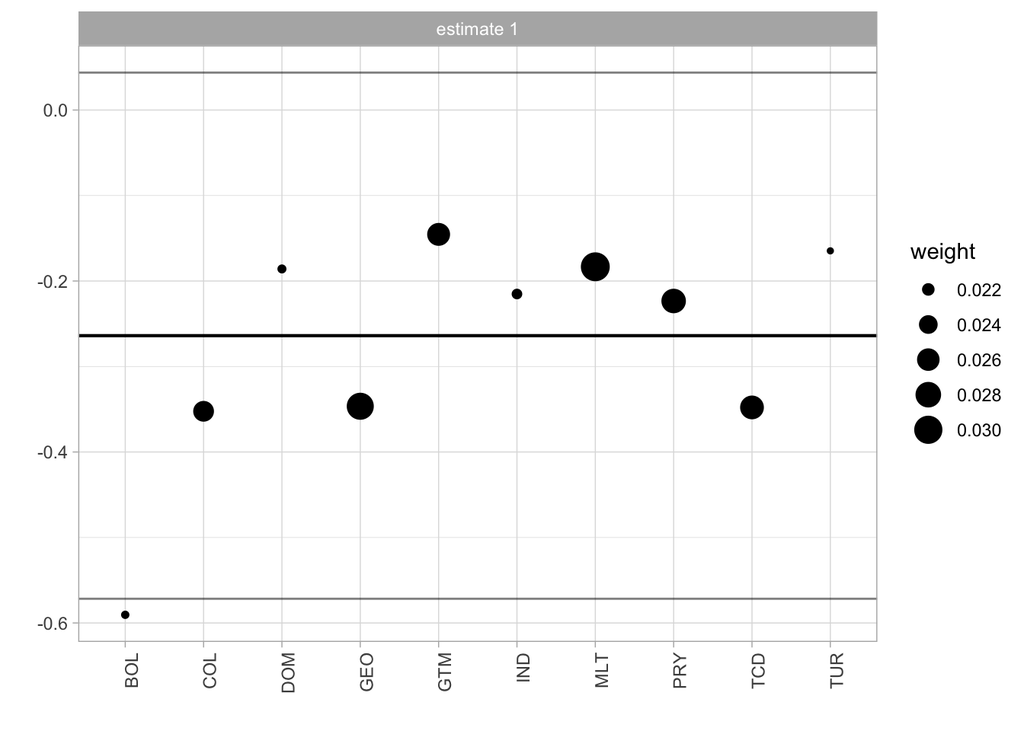

Weights of countries contributing to the synthetic control in the Brazilian SDiD model. Note: Unit = synthetic-control unit weights (unitless, sum to 1). Time window = weights are estimated from the pre-treatment period ending in 2008. Treatment definition = Treatment indicator equals 1 from 2009 onward, when China becomes Brazil’s top export destination displacing the USA, and 0 before 2009.

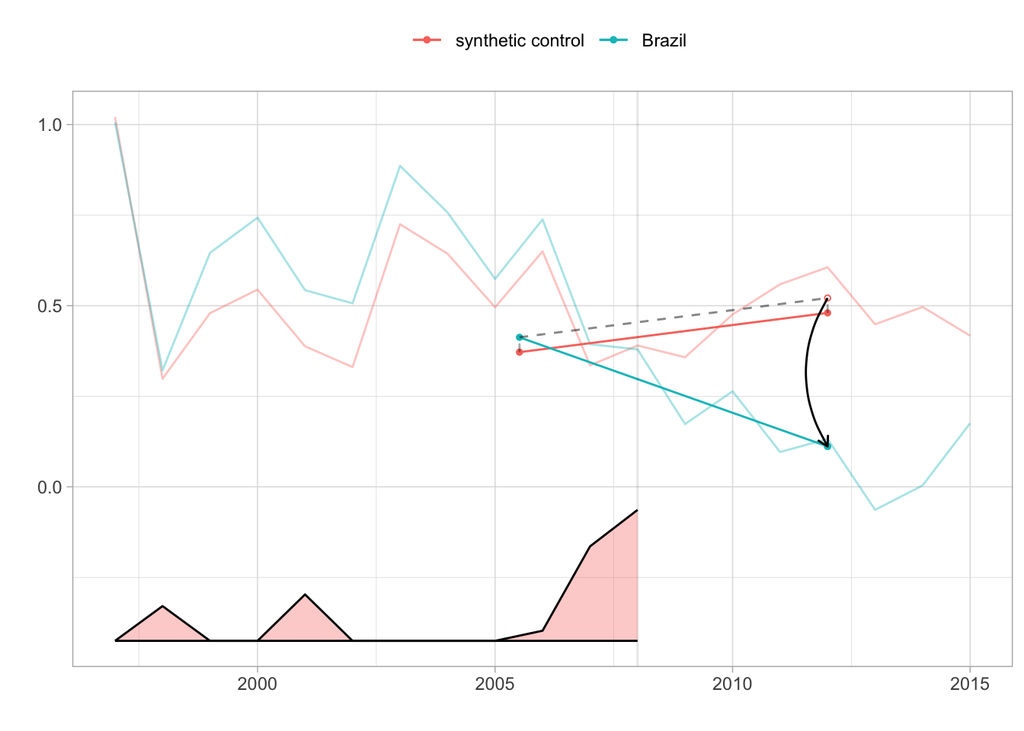

SDiD fit with a Latin American donor pool. Note: Unit = absolute UNGA ideal-point distance to China (points). Standard error = placebo-based (reported in text; not plotted here). Time window = pre-treatment and post-treatment years shown in the plot (treatment in 2009). Treatment definition = Treatment indicator equals 1 from 2009 onward, when China becomes Brazil’s top export destination displacing the USA, and 0 before 2009.

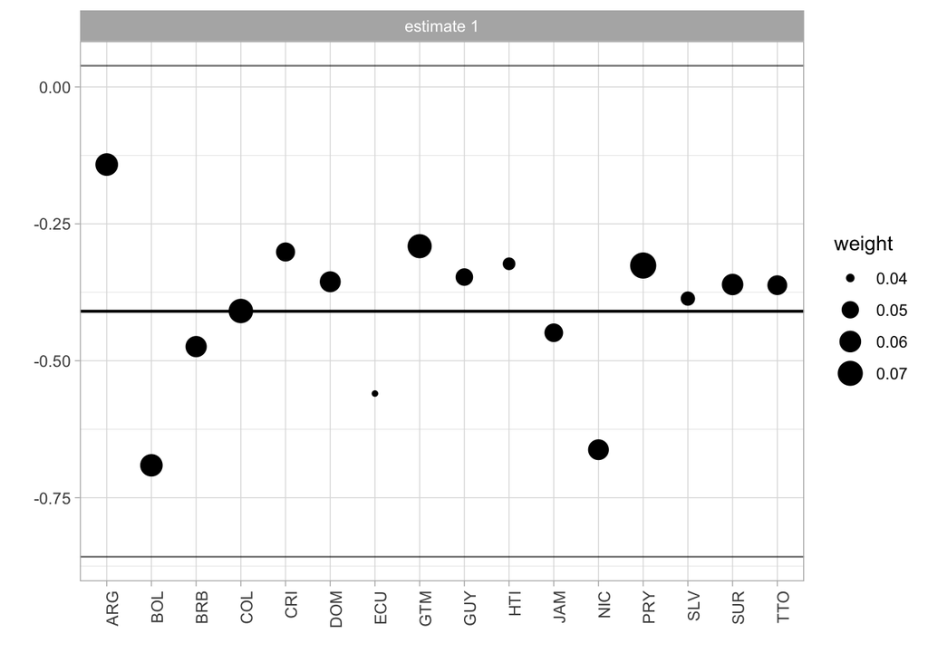

Synthetic-control donor weights for the Latin American SDiD specification. Note: Unit = synthetic-control unit weights (unitless, sum to 1). Time window = weights are estimated from the pre-treatment period ending in 2008. Treatment definition = Treatment indicator equals 1 from 2009 onward, when China becomes Brazil’s top export destination displacing the USA, and 0 before 2009.

## Cross-Country Robustness: Absorbing-Treatment Estimator (C&S)

As a robustness check, we also report results from the Callaway and Sant’Anna (2021) absorbing-treatment estimator, restricted to countries where China’s displacement of the USA was never reversed (7 countries). This estimator assumes that treatment is permanent once assigned – an assumption violated for 52 of the 59 treated countries but appropriate for the absorbing subset. The absorbing-only C&S ATT (-0.117, SE = 0.045, p = 0.009) is directionally consistent with the fect IFE result, confirming that the finding is not an artifact of the switching-treatment framework.

With only 7 treated countries in the absorbing subset, asymptotic cluster-robust inference may be liberal. We address this concern with two finite-sample procedures applied to the full C&S sample.

**Wild cluster bootstrap.** We stack the staggered treatments into a single DiD specification and apply the wild cluster bootstrap with Webb weights (MacKinnon and Webb 2018), using 9,999 replications. The stacked DiD coefficient is -0.160 (cluster SE = 0.046) with a bootstrap p-value of 0.019 and 95% bootstrap CI [-0.274, -0.045], based on 67 clusters. The result remains statistically significant under this more conservative inference procedure.

**Fisher randomization test.** To provide exact inference that does not rely on large-sample asymptotics, we randomly reassign treatment status across countries and re-estimate the overall ATT under each permutation. The observed ATT (-0.117) is more extreme than 96.7% of the 1000 valid permutation estimates (Fisher p = 0.033).

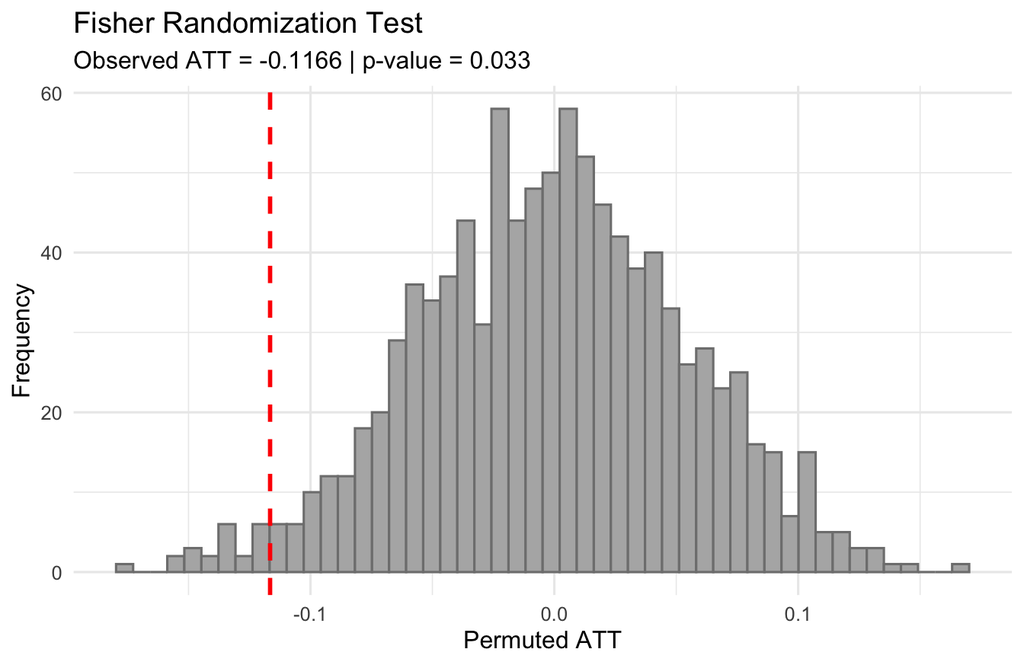

Fisher randomization distribution with the observed ATT marked by the dashed red line. Note: Unit = ATT in absolute UNGA ideal-point distance to China (points). Standard error = permutation-based exact inference. Time window = 1990-2022 balanced panel used for permutations. Treatment definition = Treatment indicator equals 1 in any year China is currently the top export destination; turns off if USA regains the position (switching treatment).

## Cross-Country Diagnostic: No-Pretrend Equivalence Tests

Following Liu, Wang, and Xu (2024) and Chiu et al. (2025), we report equivalence tests for the no-pretrend assumption. Unlike the conventional placebo test (which tests $H_0$: no pre-trend), the equivalence test reverses the null to $H_0$: pre-trends are meaningfully large, providing positive evidence for the absence of pre-trends when rejected. The red dashed lines mark the equivalence range ($0.36\hat{\delta}_s$ or the user-specified threshold), while the grey dashed lines mark the minimum range.

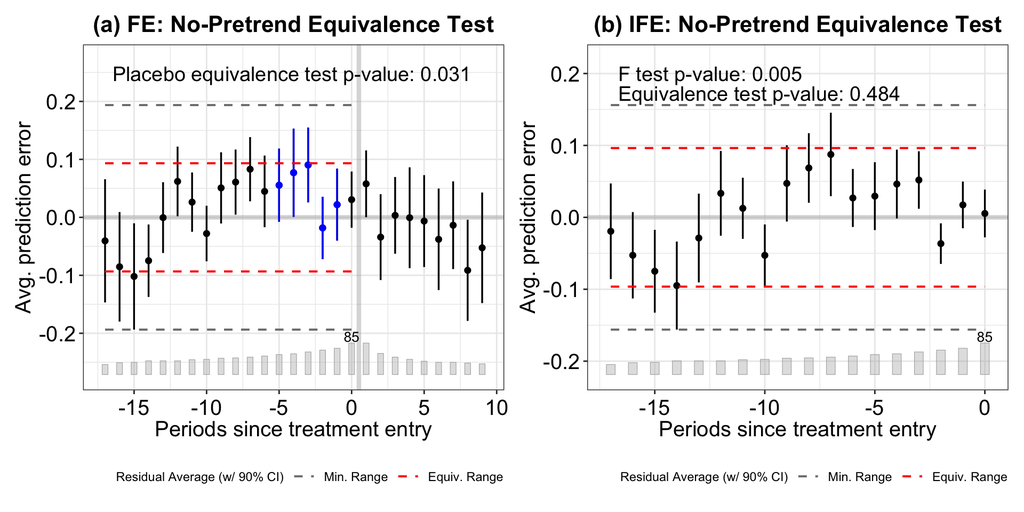

## ChatGPT Classification

Below is the coded instruction to the ChatGPT API to classify the subjects of the headlines.

```r
system_block <- paste(
  'You are a Brazilian expert in International Relations and the political',
  'economy of China–Brazil relations.  Classify the subject of EACH headline',
  'when I say EACH, I mean all of them, even if repetitive or similar. Do classify **all** of them',
  'using **one** label from this list exactly as written:',
  '"diplomacy", "chinese economy", "china-brasil relations",',
  '"disaster and accidents", "chinese politics and policy",',
  '"sports, science, culture, other", "human rights",',
  '"china-brazil trade", "health".\n\n',
  # 13 static few-shot examples — leave them unchanged!
  'Examples:\n',
  '1. Presidente chinês visita o Brasil e participa de reunião com FHC -> china-brasil relations\n',
  '2. Ministro chinês de Defesa faz visita oficial ao Brasil -> china-brasil relations\n',
  '3. Para governo, novo câmbio chinês só beneficia Brasil no médio prazo -> china-brazil trade\n',
  '4. China ultrapassa EUA como maior parceiro comercial do Brasil -> china-brazil trade\n',
  '5. China vai controlar preços de alimentos e combustíveis -> chinese economy\n',
  '6. Vendas de automóveis na China desaceleram em junho -> chinese economy\n',
  '7. China quer devolução das relíquias Yin, patrimônio da Unesco -> sports, science, culture, other\n',
  '8. Dinossauro encontrado na China esclarece origem das aves -> sports, science, culture, other\n',
  '9. OMS confirma mais de 4.600 casos de gripe suína; China registra 2º caso -> health\n',
  '10. Marinha chinesa busca "cansar" barcos japoneses em águas disputadas -> diplomacy\n',
  '11. Acidente após casamento deixa 16 mortos na China -> disaster and accidents\n',
  '12. Jornal chinês sai das bancas por foto da praça Tiananmen -> human rights\n',
  '13. China é parceira estratégica contra crise econômica, diz UE -> chinese economy',
  'return as in the examples, a string with the headline and the classification'
)
```

It is important to highlight that the process was not streamlined. We faced several problems, such as ChatGPT refusing to classify subjects (saying they were repetitive and too similar), changing the original headline, which made matching back to the original dataset difficult, and other similar problems. As a result, we had to rerun the instructions a few times on a sample and tweak it with some prompt engineering until arriving at that final version. As a result, this is the only part of the paper not fully reproducible, in the sense that another request for classification, with the same instructions, would yield a few different categorizations and a few different original headlines changed, along with some refusals to classify texts.

Below we provide a random sample of the headlines and the classification provided by ChatGPT.

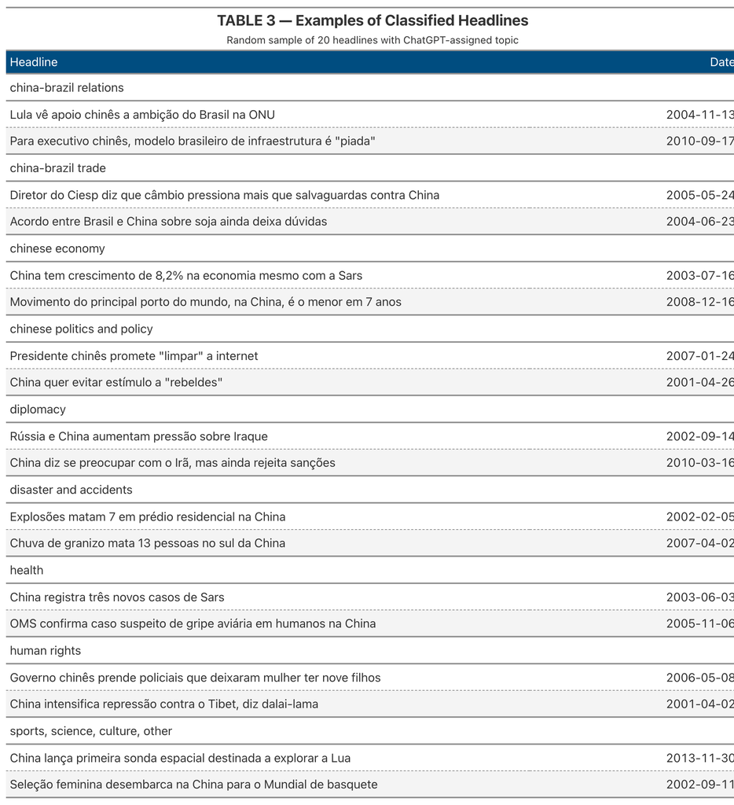

Random sample of China-related Folha de Sao Paulo headlines and ChatGPT classifications. Note: Unit = headline text and category labels. Time window = sample drawn from the 2000-2014 corpus.

### Validation of ChatGPT Classification

To assess the reliability of the automated classification, one of the authors independently coded a stratified random sample of 100 headlines (with a minimum of 5 per category). Table @ref(tab:chatgpt-validation) reports the agreement rate between the ChatGPT labels and the manual coding.

Validation of ChatGPT classification against manual coding (N = 100). Overall accuracy: 88.0 percent.

| Category | N | Correct | Accuracy (%) |
| --- | --- | --- | --- |
| china-brazil trade | 6 | 6 | 100.0 |
| disaster and accidents | 13 | 13 | 100.0 |
| health | 6 | 6 | 100.0 |
| chinese economy | 25 | 24 | 96.0 |
| human rights | 8 | 7 | 87.5 |
| diplomacy | 12 | 10 | 83.3 |
| sports, science, culture, other | 17 | 14 | 82.4 |
| china-brazil relations | 5 | 4 | 80.0 |
| chinese politics and policy | 8 | 4 | 50.0 |
| Overall | 100 | 88 | 88.0 |

Note: Unit = headline-level counts and accuracy (percent) by category. Time window = stratified validation sample from the 2000-2014 headline corpus.

The overall accuracy is 88%. The lowest agreement is in the “chinese politics and policy” category (50%), where several headlines were manually reclassified as “diplomacy”. The categories most relevant to our analysis — “china-brazil trade” and “disaster and accidents” — achieved 100% agreement.

## Cross-Country: Treated Countries and Treatment-Switching Diagnostic

The dynamic event study below displays the estimated ATT at each period relative to treatment across C&S specifications (absorbing-only). These are provided for comparison with the main fect IFE results reported in the body of the paper.

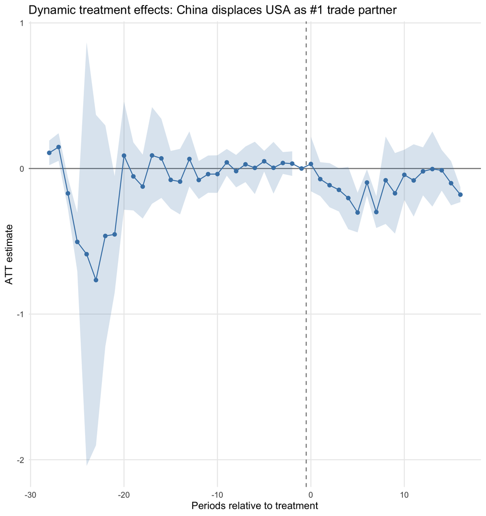

Dynamic treatment effects across C&S specifications (absorbing treatment). Note: Unit = ATT in absolute UNGA ideal-point distance to China (points). Standard error = analytical (95 percent confidence intervals shown). Cluster = country level. Time window = 1990-2022 baseline panel and 1995-2022 restricted panel, depending on specification. Treatment definition = absorbing treatment: equals 1 from first year China becomes top partner, assumes no reversal.

[^1]: The most ambitious causal study in this tradition, Flores-Macías and Kreps (2013), employs fixed-effects with lagged dependent variables and two-stage least squares. Both strategies face well-documented identification problems: the lagged dependent variable violates the no-carryover assumption required for FE consistency (Blackwell and Glynn 2018; Imai and Kim 2019, 2021), and the instrument (lagged energy production) likely fails the exclusion restriction (Mellon 2021; Bastardoz et al. 2023; Lal et al. 2024).
[^2]: A figure with the weights for top controls is in the appendix
[^3]: Adding higher-order polynomial terms of trade shares (quadratic, cubic) is not advisable in this context, as Gelman and Imbens (2019) show that polynomial specifications produce noisy estimates with poor confidence-interval coverage, a concern that applies a fortiori in an underpowered single-treated-unit design.
[^4]: We used ChatGPT 4o to assist in the headlines translation from Portuguese into English. See https://chatgpt.com/share/6862b919-4630-800e-ab9c-df9dee5ae56c
[^5]: We thank an anonymous reviewer for raising the possibility that the effect might dissipate over time.